# Analisis Tesis

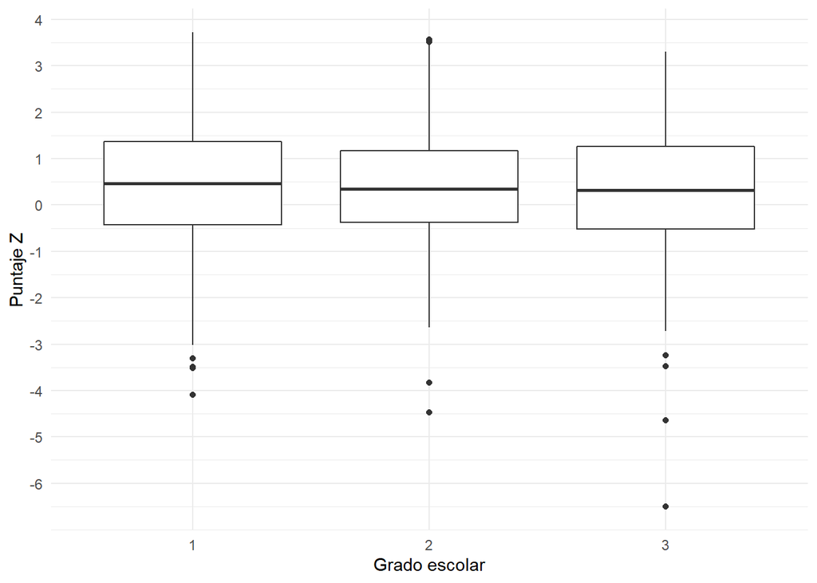

Histograma y QQPLOT de distribucion de puntaje z para edad

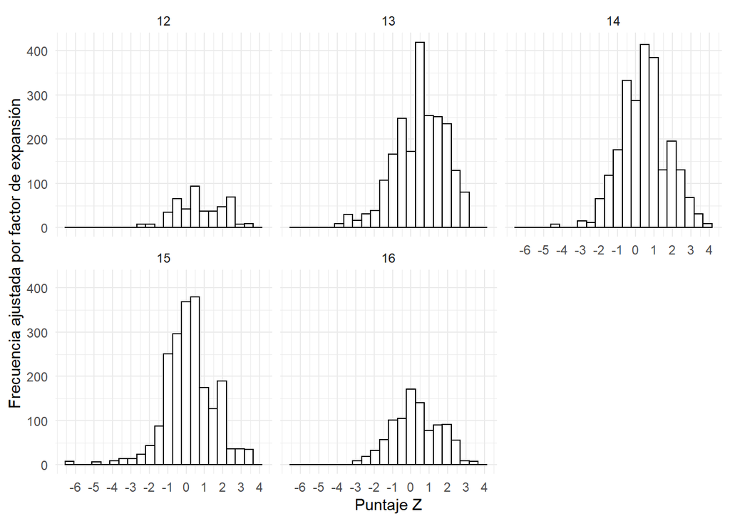

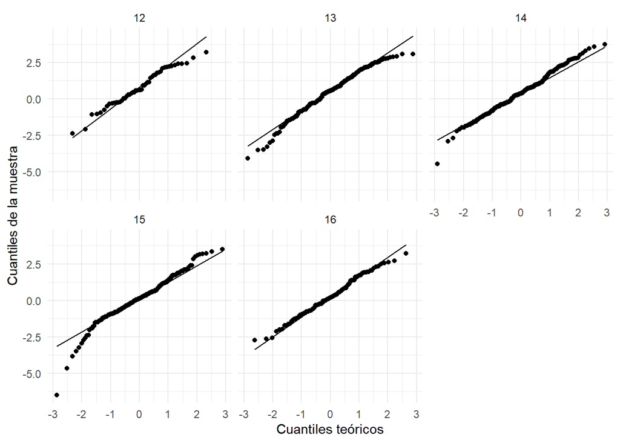

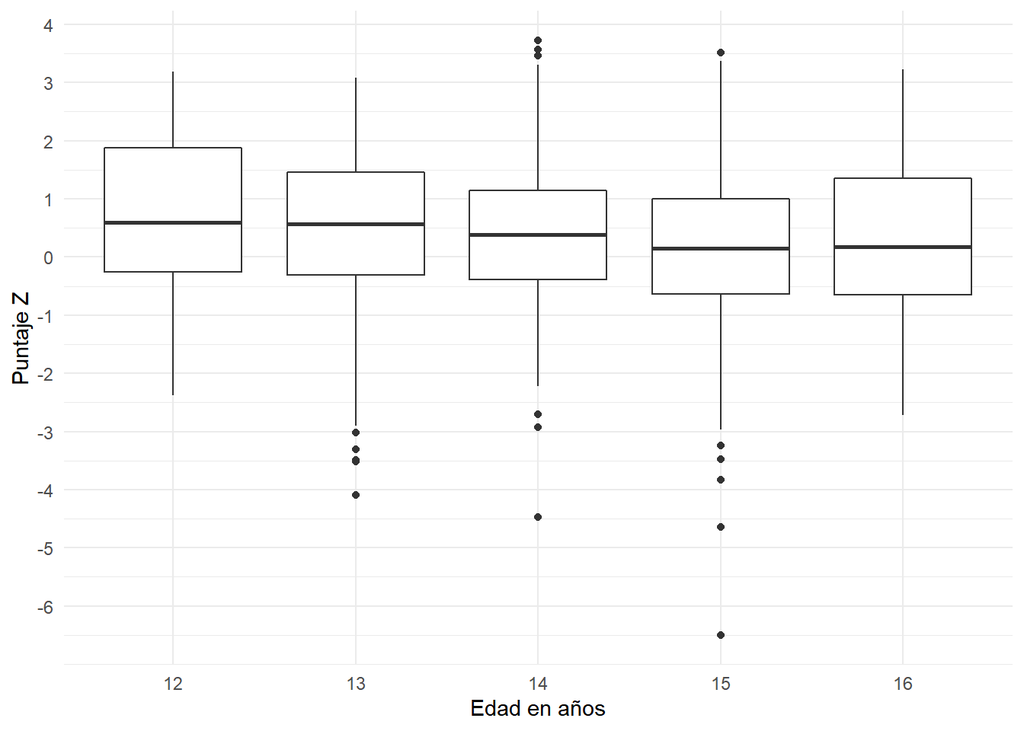

ANALISIS GRAFICO DE PAQ A

Distribucion de toda la poblacion de PAQ - A

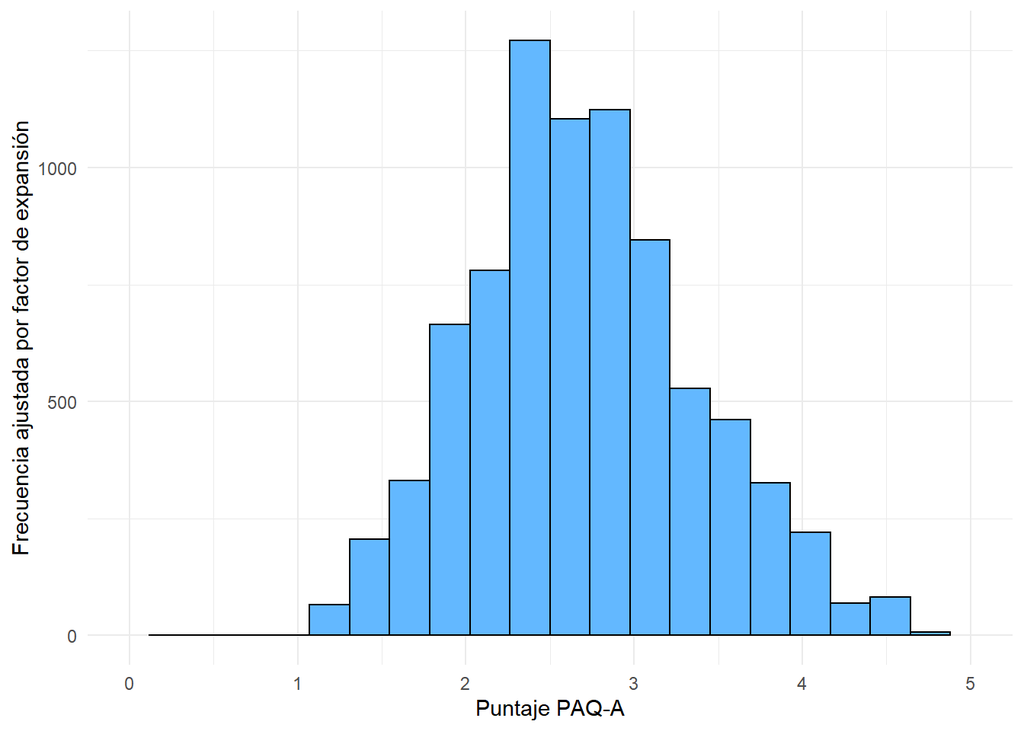

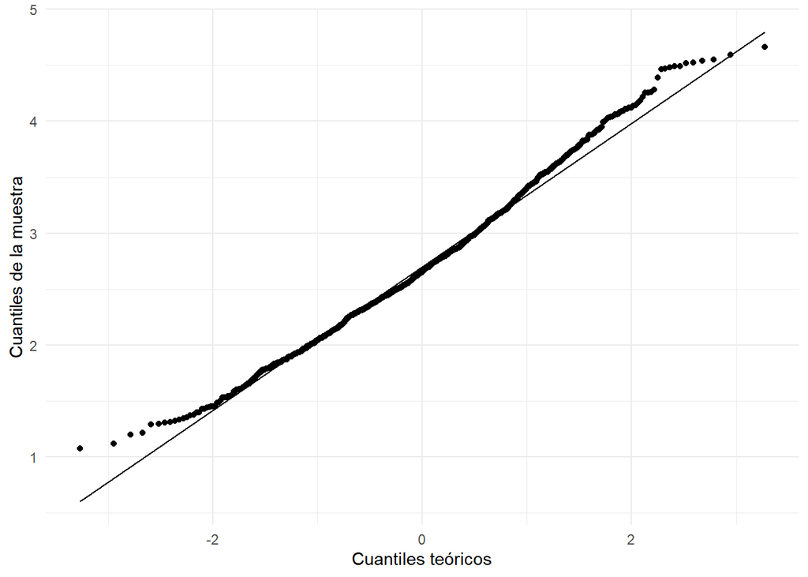

Histograma Y QQPLOT de distribucion de puntaje PAQA para sexo

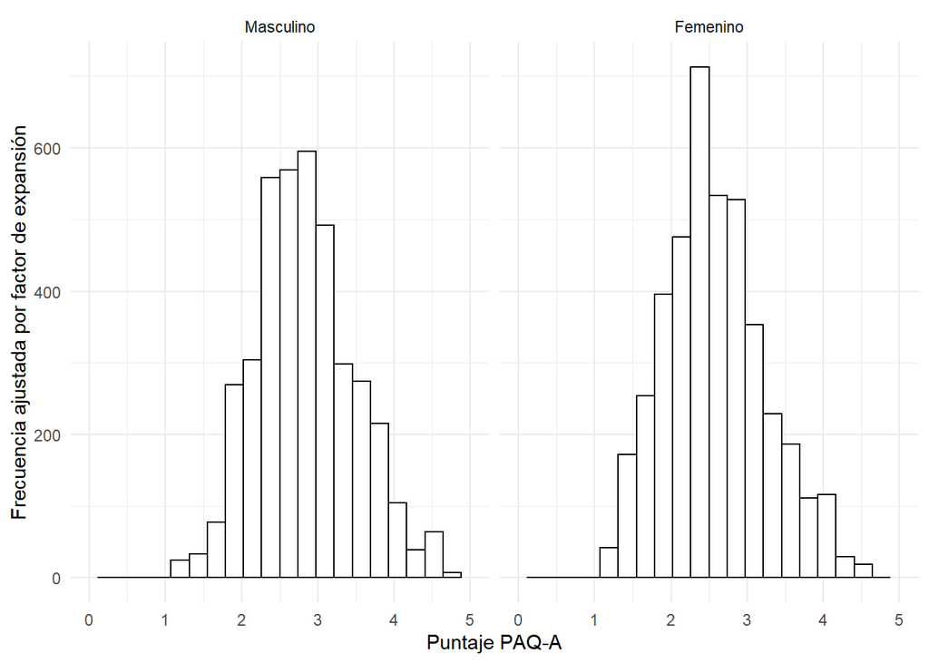

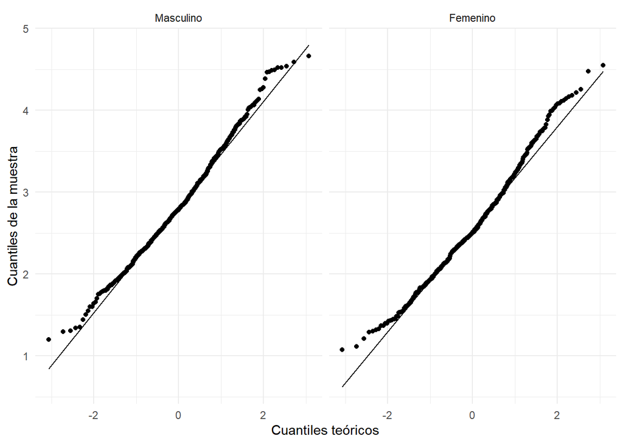

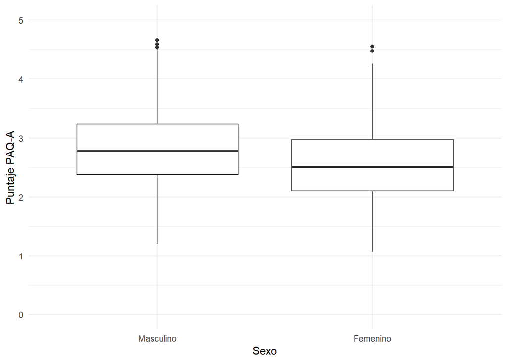

Histograma y QQPLOT de distribucion de puntaje PAQA para area historica

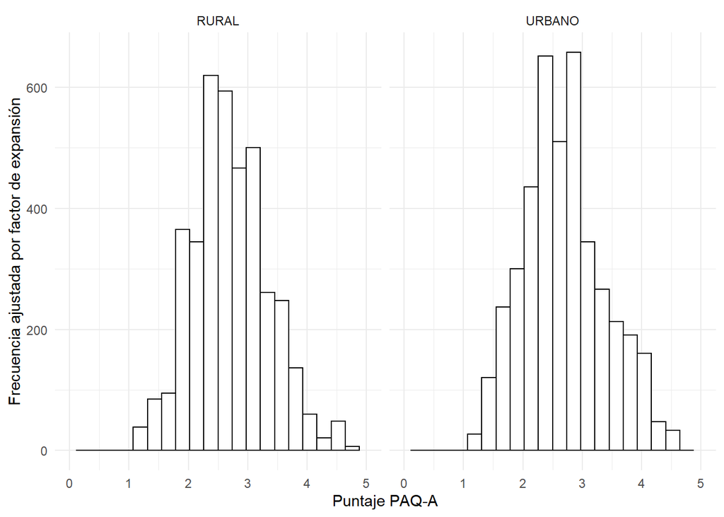

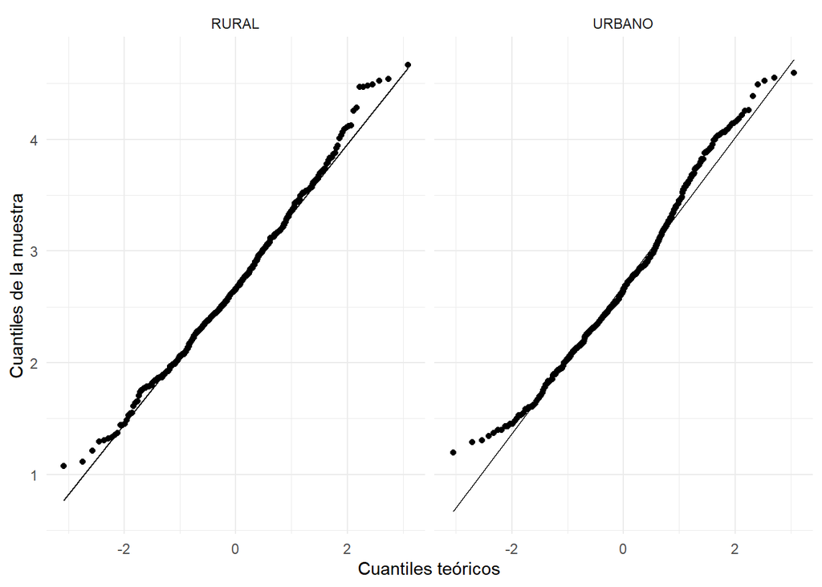

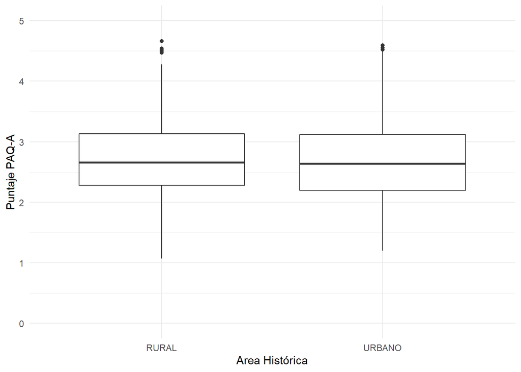

Histograma y QQPLOT de distribucion de PAQA para sector historico

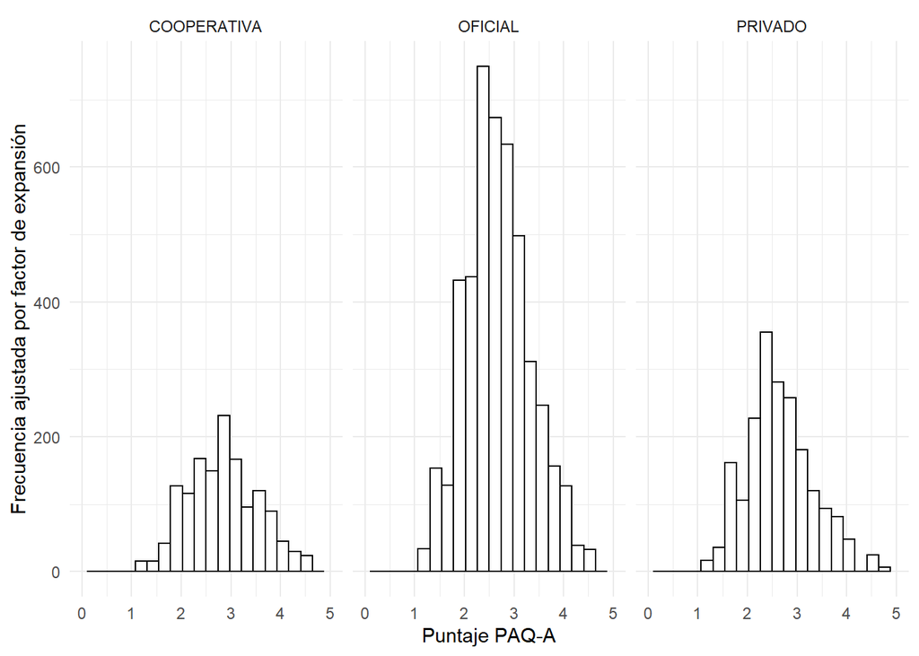

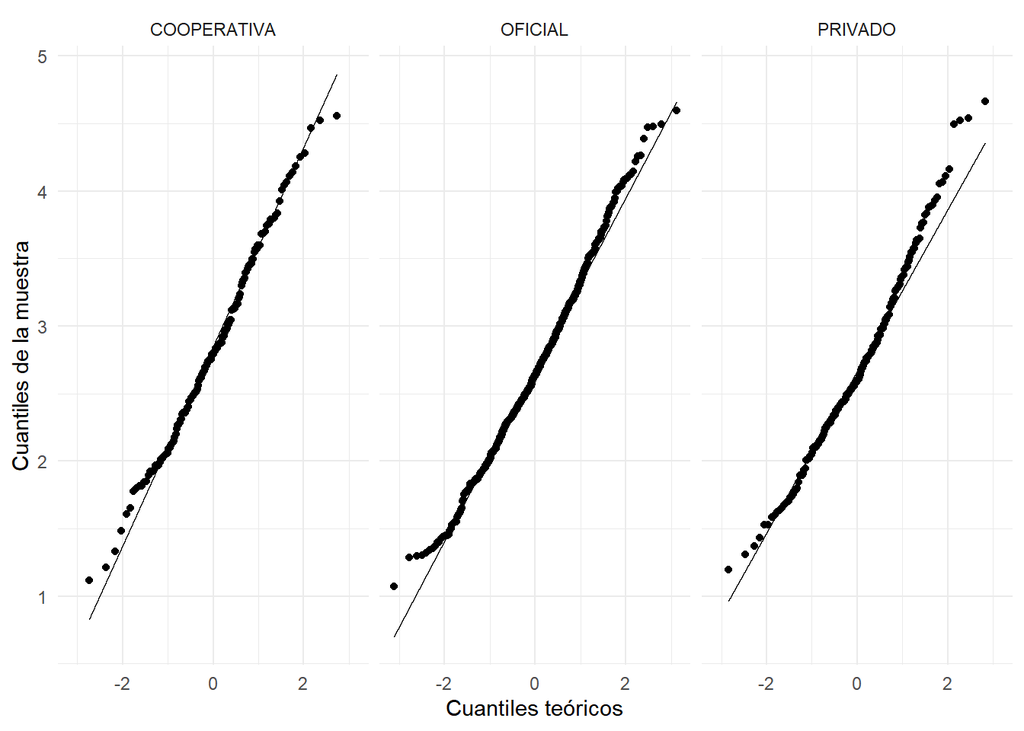

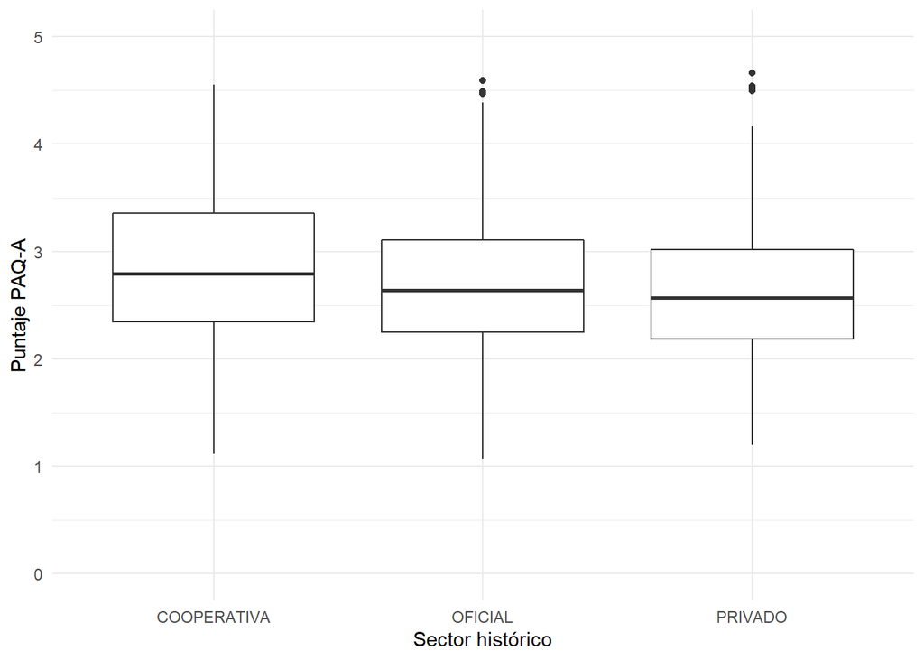

Histograma y QQPLOT de distribucion de PAQA para grado

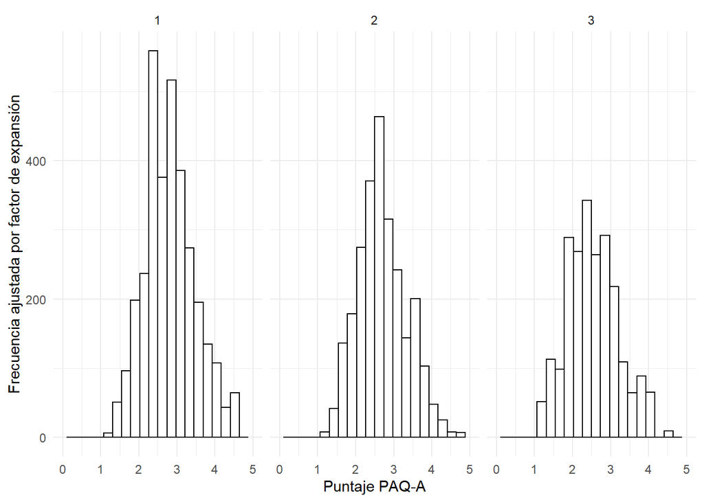

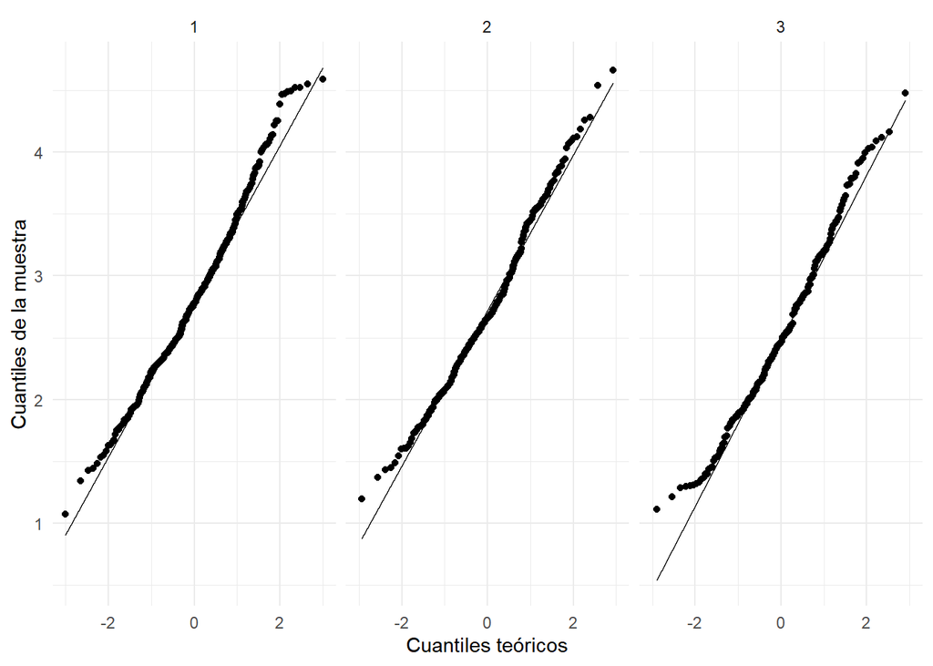

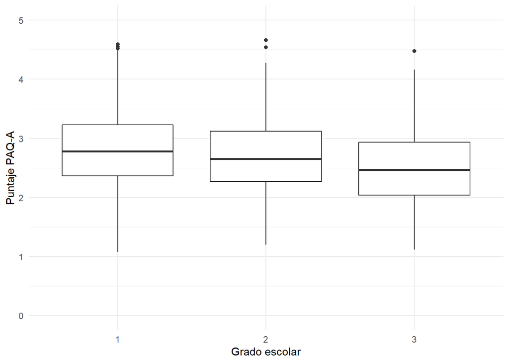

Histograma y QQPLOT de distribucion de PAQA para edad

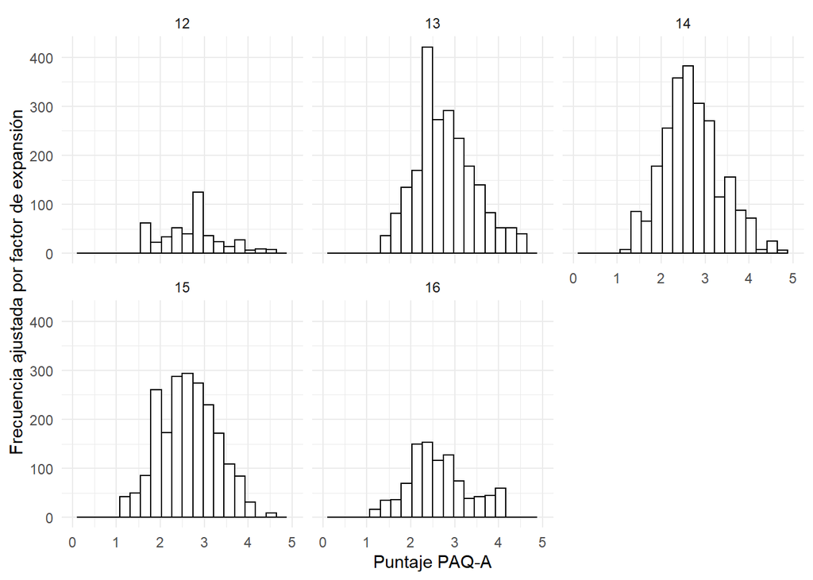

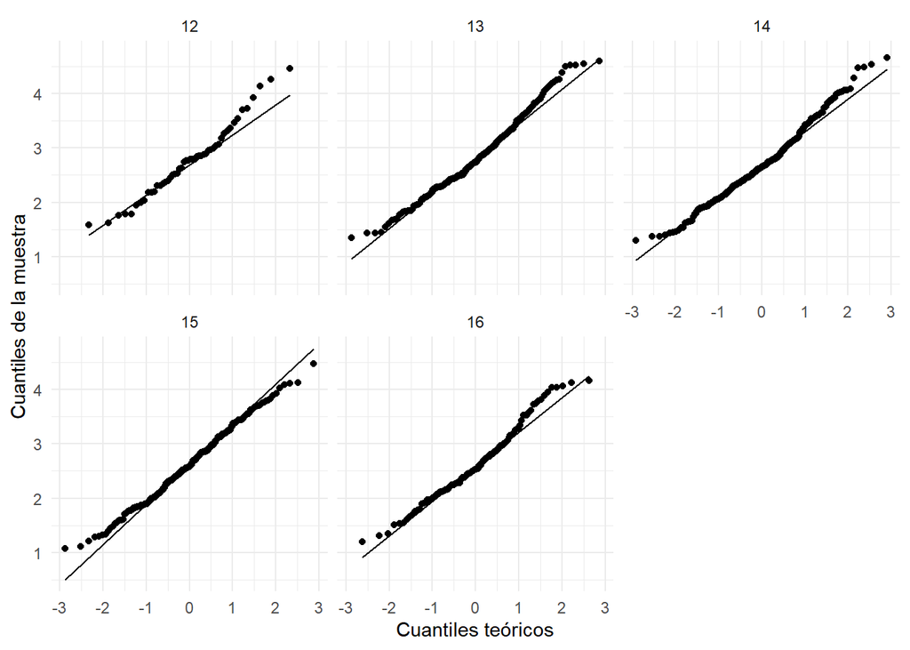

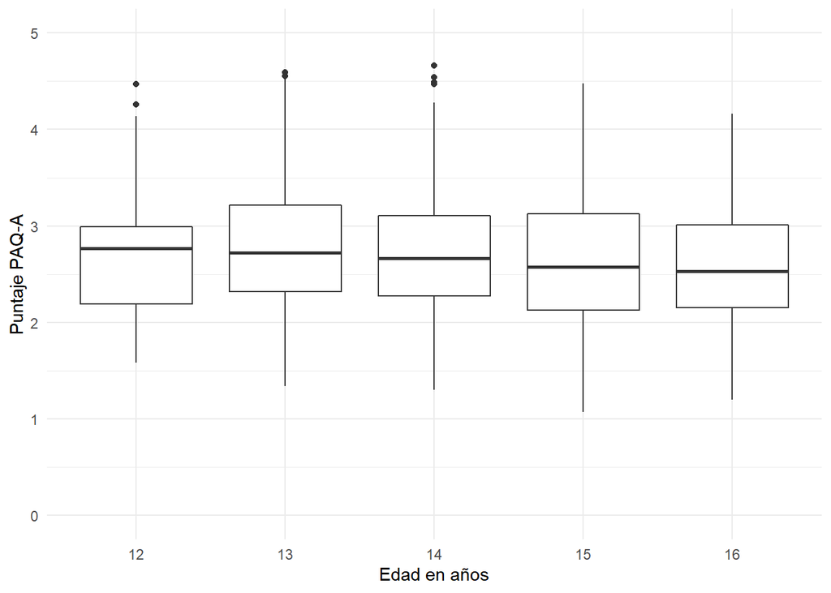

ANALISIS GRAFICO DE AFHC

Distribucion de toda la poblacion de AFHC

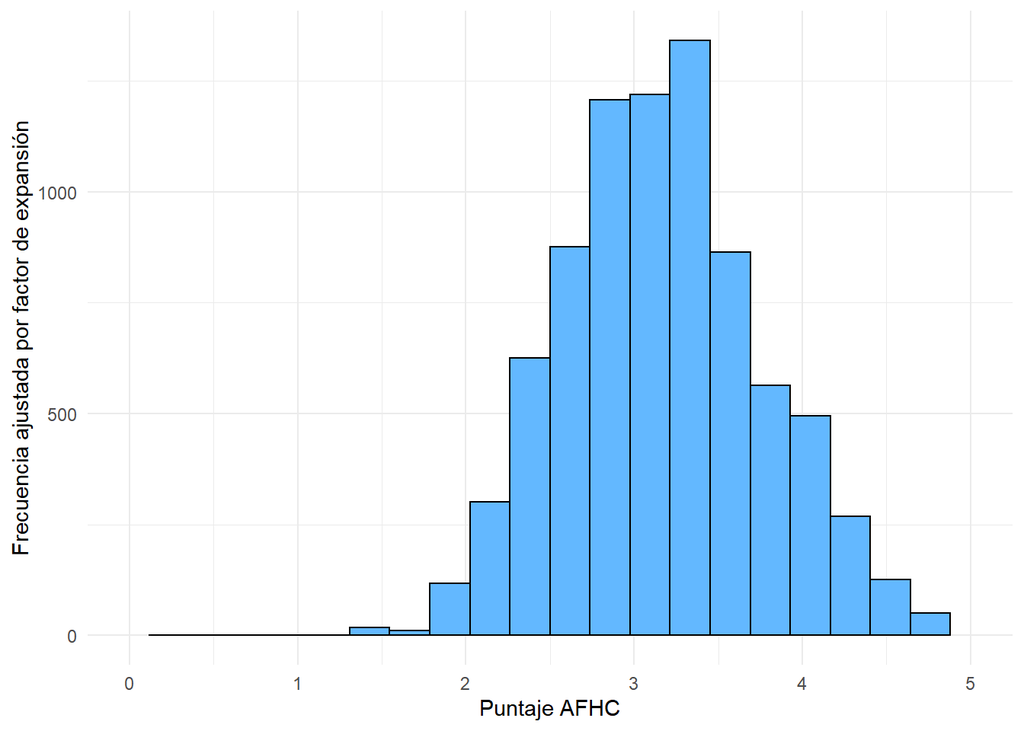

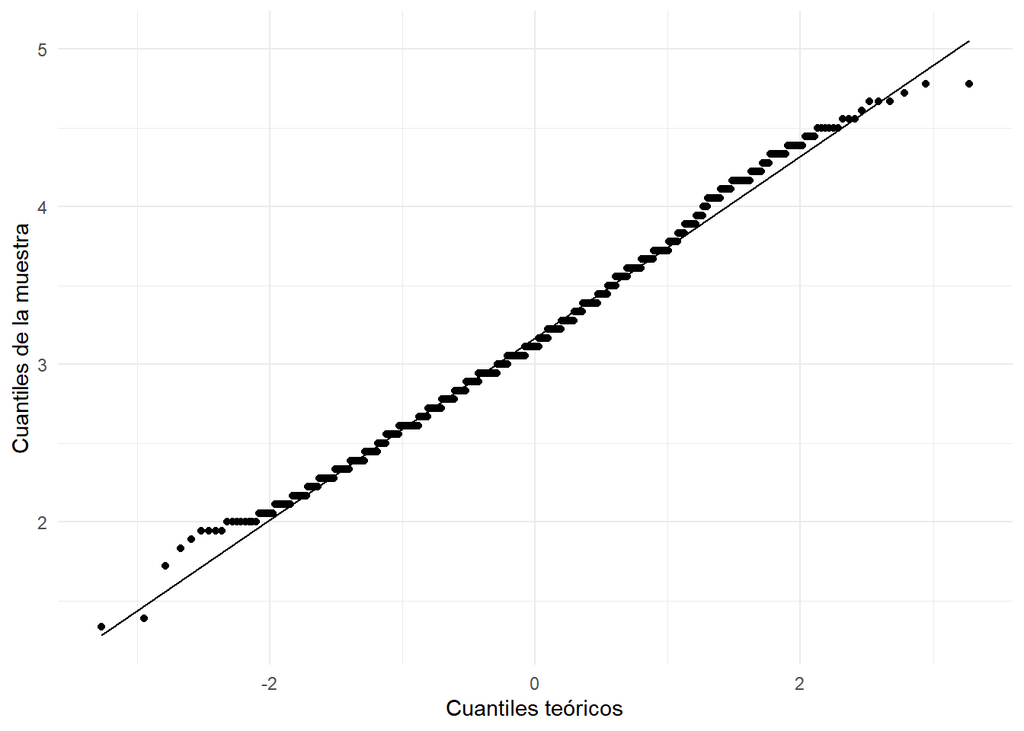

Histograma Y QQPLOT de distribucion de puntaje AFHC para sexo

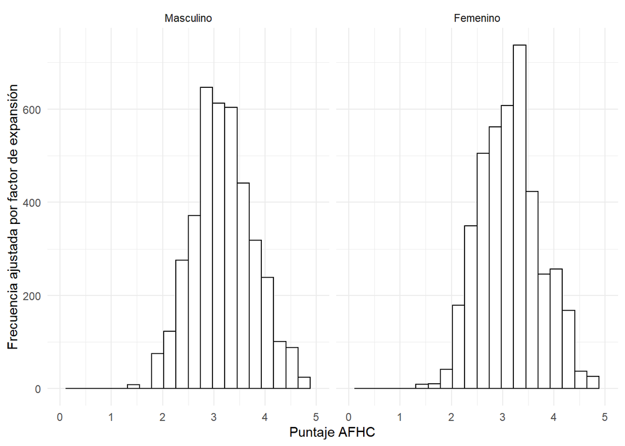

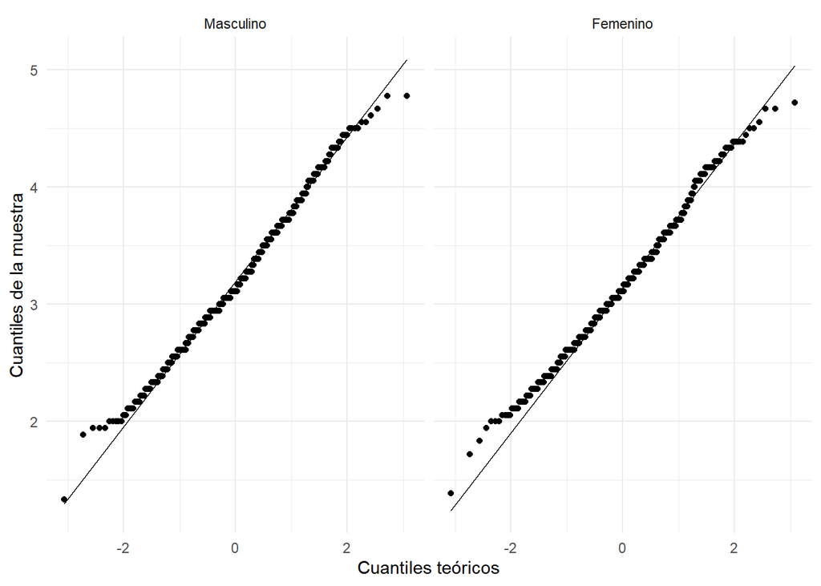

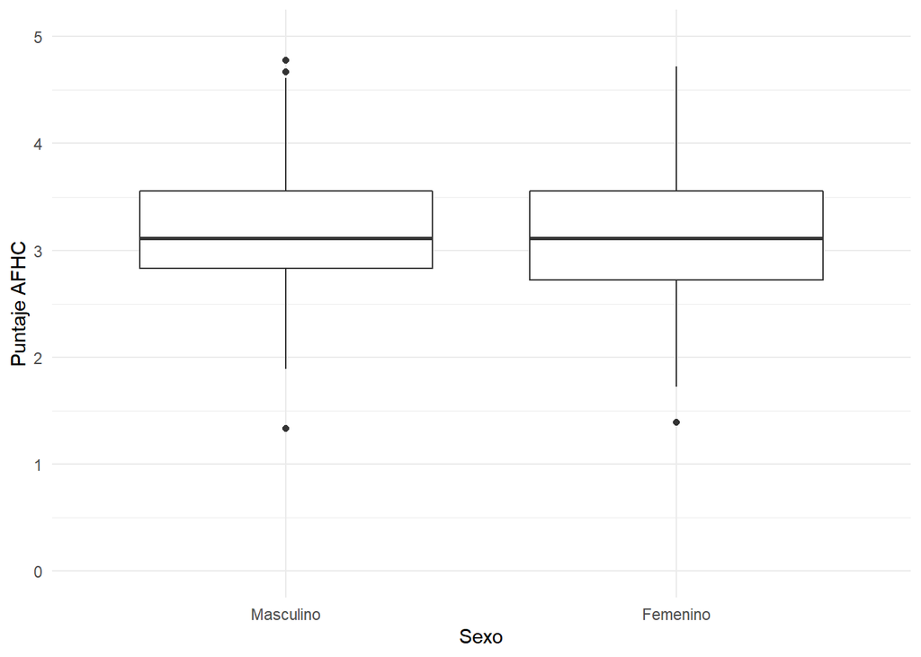

Histograma y QQPLOT de distribucion de puntaje AFHC para area historica

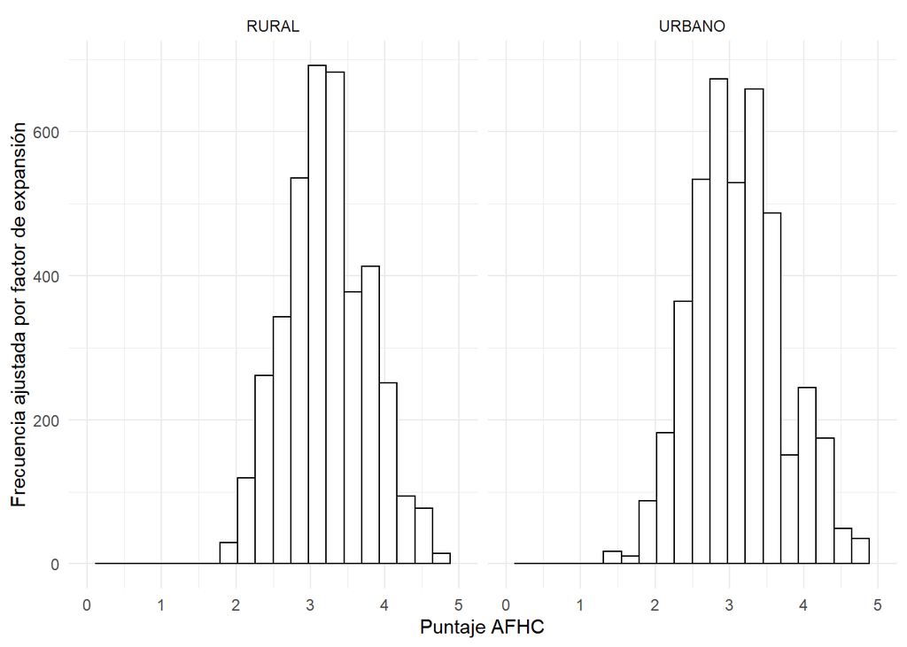

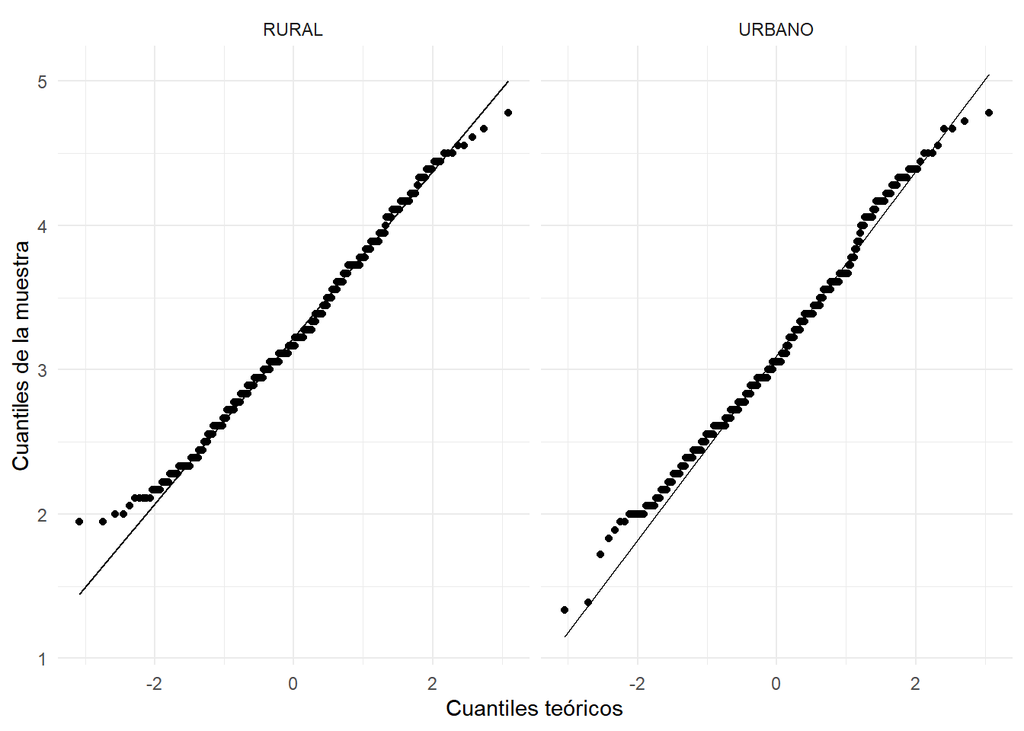

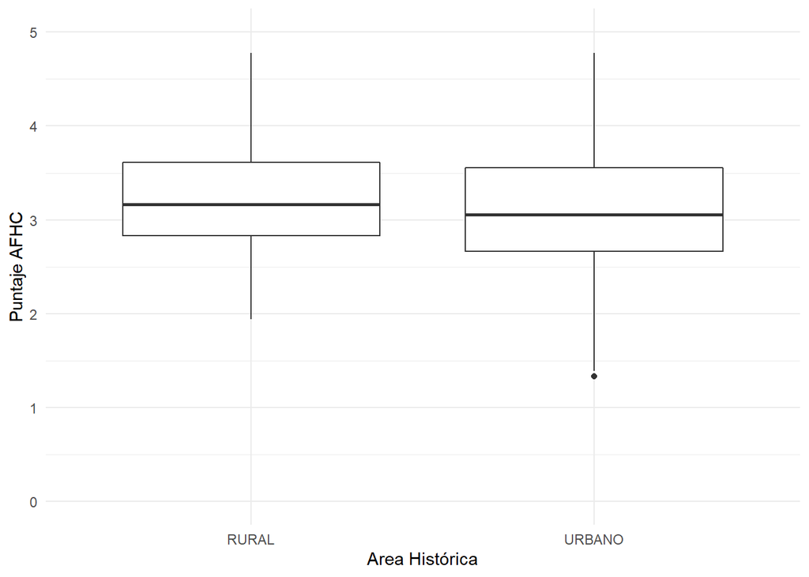

Histograma y QQPLOT de distribucion de AFHC para sector historico

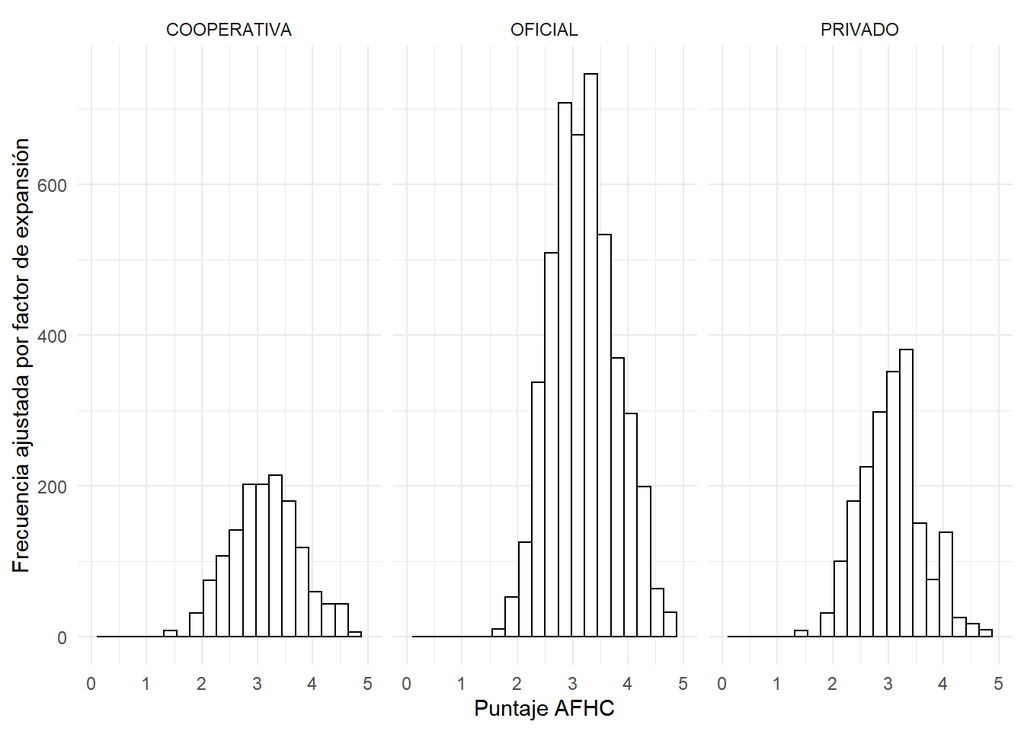

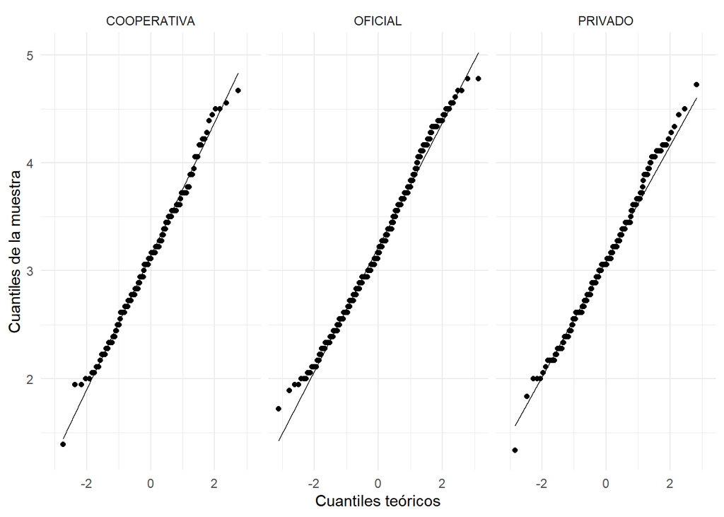

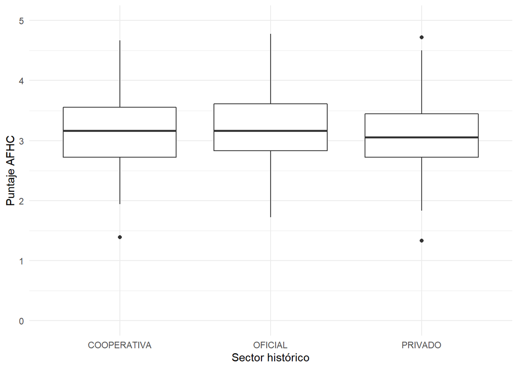

Histograma y QQPLOT de distribucion de AFHC para grado

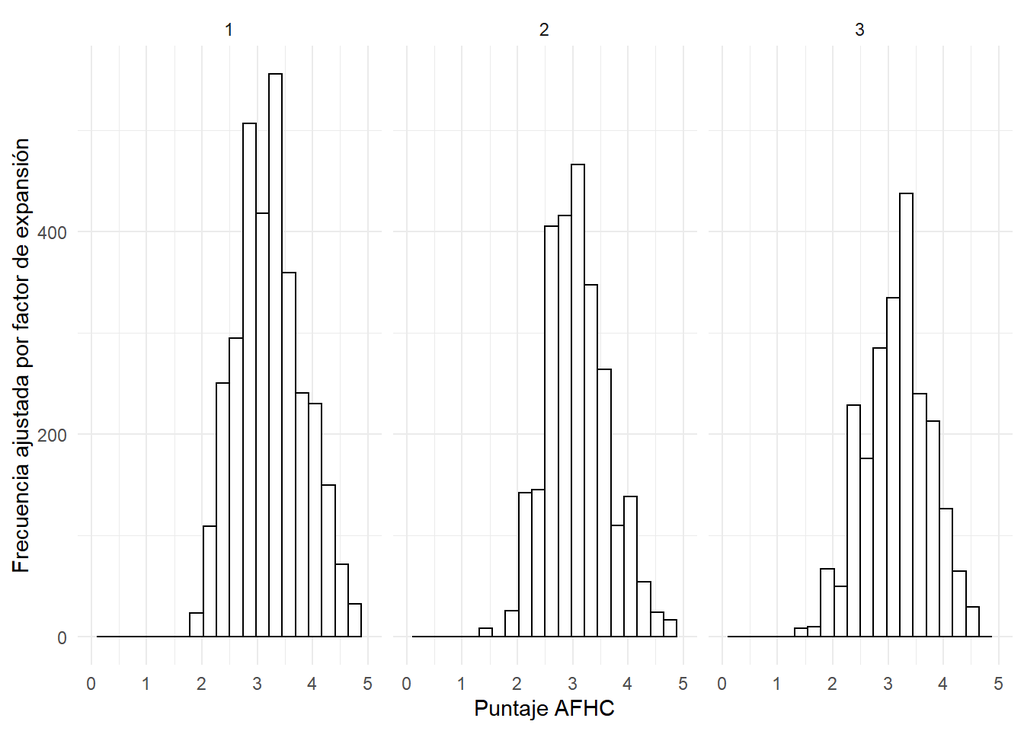

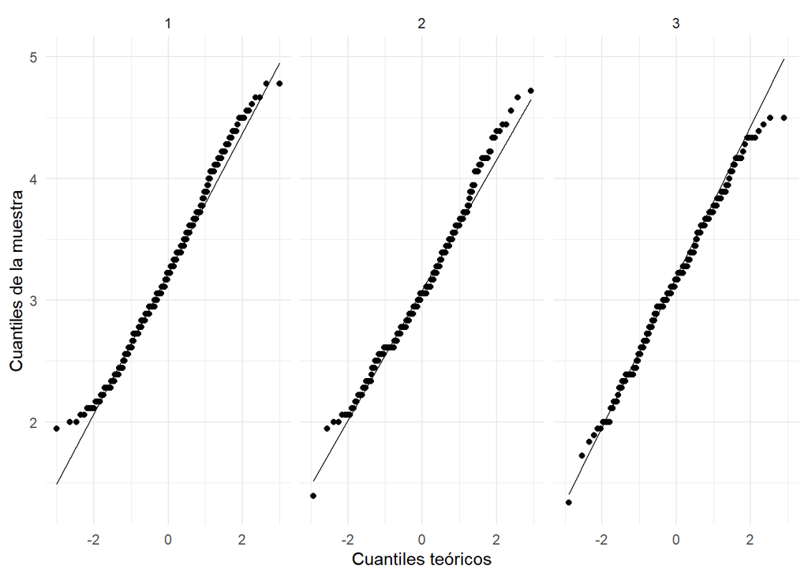

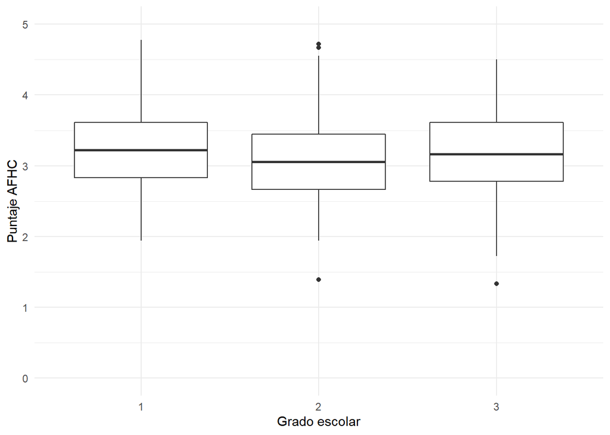

Histograma y QQPLOT de distribucion de AFHC para edad

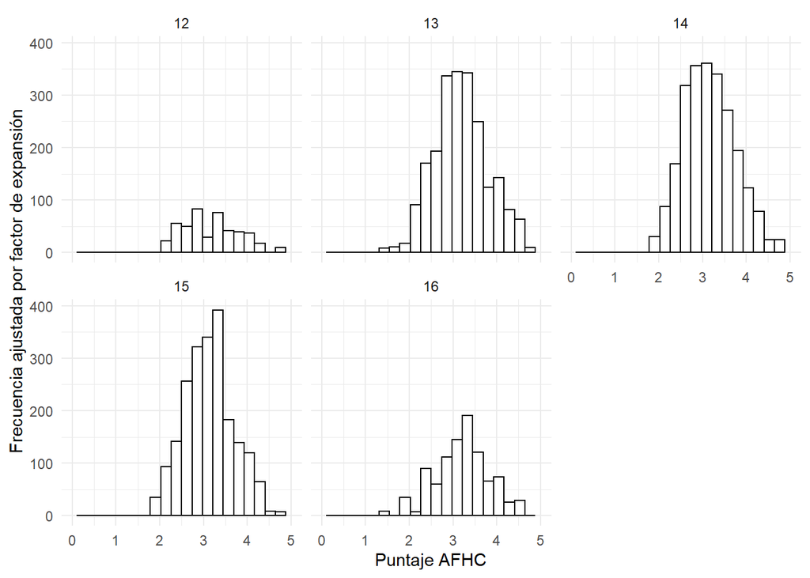

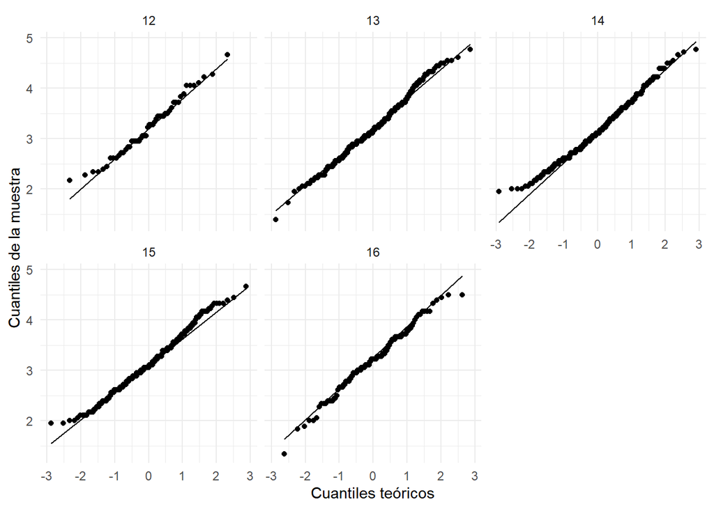

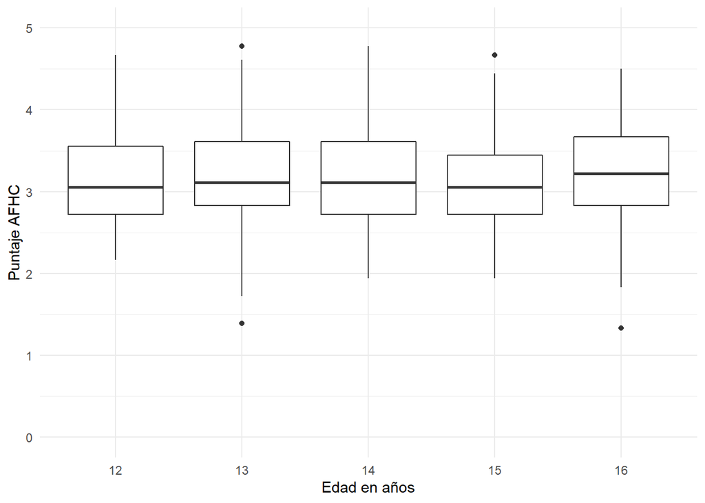

ANALISIS NUMERICO DE PUNTAJE Z

Estadisticas de resumen de puntaje z para toda la poblacion

```
##       meanz      sdz   medianz      IQRz     maxz      minz
## 1 0.3814984 1.321965 0.3719243 0.4318961 3.721839 -6.507249
```

Estadisticas de resumen de puntaje z por sexo

```
## # A tibble: 2 x 7
##   `as.factor(sexo)` meanz   sdz medianz  IQRz  maxz  minz
##   <fct>             <dbl> <dbl>   <dbl> <dbl> <dbl> <dbl>
## 1 1                 0.461  1.45   0.469 0.497  3.72 -6.51
## 2 2                 0.307  1.19   0.301 0.399  3.37 -4.47
```

Estadisticas de resumen de puntaje z por area historica

```
## # A tibble: 2 x 7
##   areahist meanz   sdz medianz  IQRz  maxz  minz
##   <fct>    <dbl> <dbl>   <dbl> <dbl> <dbl> <dbl>
## 1 RURAL    0.240  1.21   0.275 0.522  3.46 -6.51
## 2 URBANO   0.512  1.40   0.553 0.365  3.72 -4.64
```

Estadisticas de resumen de puntaje z por sector historico

```
## # A tibble: 3 x 7
##   sectorhist  meanz   sdz medianz  IQRz  maxz  minz
##   <fct>       <dbl> <dbl>   <dbl> <dbl> <dbl> <dbl>
## 1 COOPERATIVA 0.540  1.44   0.599 0.389  3.57 -6.51
## 2 OFICIAL     0.216  1.23   0.185 0.529  3.52 -4.09
## 3 PRIVADO     0.653  1.39   0.689 0.322  3.72 -4.47
```

Estadisticas de resumen de puntaje z por grado

```
## # A tibble: 3 x 7
##   `as.factor(grado)` meanz   sdz medianz  IQRz  maxz  minz
##   <fct>              <dbl> <dbl>   <dbl> <dbl> <dbl> <dbl>
## 1 1                  0.402  1.35   0.460 0.425  3.72 -4.09
## 2 2                  0.401  1.29   0.340 0.376  3.57 -4.47
## 3 3                  0.330  1.32   0.322 0.522  3.30 -6.51
```

Estadisticas de resumen de puntaje z por edad en aÃ±os

```
## # A tibble: 5 x 7
##   edada.os meanz   sdz medianz  IQRz  maxz  minz
##      <int> <dbl> <dbl>   <dbl> <dbl> <dbl> <dbl>
## 1       12 0.777  1.25   0.589 0.262  3.19 -2.38
## 2       13 0.485  1.36   0.568 0.313  3.08 -4.09
## 3       14 0.437  1.27   0.385 0.389  3.72 -4.47
## 4       15 0.175  1.33   0.149 0.632  3.52 -6.51
## 5       16 0.271  1.28   0.173 0.648  3.23 -2.72
```

ANALISIS NUMERICO DE PUNTAJE PAQA

Estadisticas de resumen de puntaje PAQA para toda la poblacion

```
##   meanpaqa    sdpaqa medianpaqa  IQRpaqa  maxpaqa  minpaqa
## 1 2.701114 0.6718512   2.651812 -2.25094 4.663534 1.073308
```

Estadisticas de resumen de PAQA por sexo

```
## # A tibble: 2 x 7
##   `as.factor(sexo)` meanpaqa sdpaqa medianpaqa IQRpaqa maxpaqa minpaqa
##   <fct>                <dbl>  <dbl>      <dbl>   <dbl>   <dbl>   <dbl>
## 1 1                     2.83  0.655       2.78   -2.37    4.66    1.20
## 2 2                     2.58  0.664       2.50   -2.10    4.55    1.07
```

Estadisticas de resumen de PAQA por area historica

```
## # A tibble: 2 x 7
##   areahist meanpaqa sdpaqa medianpaqa IQRpaqa maxpaqa minpaqa
##   <fct>       <dbl>  <dbl>      <dbl>   <dbl>   <dbl>   <dbl>
## 1 RURAL        2.71  0.647       2.65   -2.28    4.66    1.07
## 2 URBANO       2.70  0.694       2.64   -2.20    4.59    1.20
```

Estadisticas de resumen de PAQA por sector historico

```
## # A tibble: 3 x 7
##   sectorhist  meanpaqa sdpaqa medianpaqa IQRpaqa maxpaqa minpaqa
##   <fct>          <dbl>  <dbl>      <dbl>   <dbl>   <dbl>   <dbl>
## 1 COOPERATIVA     2.84  0.713       2.79   -2.34    4.55    1.11
## 2 OFICIAL         2.68  0.655       2.64   -2.25    4.59    1.07
## 3 PRIVADO         2.65  0.668       2.57   -2.19    4.66    1.20
```

Estadisticas de resumen de PAQA por grado

```
## # A tibble: 3 x 7
##   `as.factor(grado)` meanpaqa sdpaqa medianpaqa IQRpaqa maxpaqa minpaqa
##   <fct>                 <dbl>  <dbl>      <dbl>   <dbl>   <dbl>   <dbl>
## 1 1                      2.82  0.666       2.78   -2.36    4.59    1.07
## 2 2                      2.70  0.644       2.65   -2.27    4.66    1.20
## 3 3                      2.53  0.676       2.46   -2.03    4.48    1.11
```

Estadisticas de resumen de PAQA por edad en aÃ±os

```
## # A tibble: 5 x 7
##   edada.os meanpaqa sdpaqa medianpaqa IQRpaqa maxpaqa minpaqa
##      <int>    <dbl>  <dbl>      <dbl>   <dbl>   <dbl>   <dbl>
## 1       12     2.70  0.686       2.76   -2.19    4.47    1.59
## 2       13     2.79  0.678       2.73   -2.32    4.59    1.34
## 3       14     2.71  0.660       2.66   -2.28    4.66    1.30
## 4       15     2.62  0.657       2.57   -2.13    4.48    1.07
## 5       16     2.64  0.687       2.53   -2.15    4.16    1.20
```

ANALISIS NUMERICO DE PUNTAJE AFHC

Estadisticas de resumen de puntaje AFHC para toda la poblacion

```
##   meanafhc    sdafhc medianafhc   IQRafhc  maxafhc  minafhc
## 1 3.169753 0.5935723   3.111111 -2.777778 4.777778 1.333333
```

Estadisticas de resumen de AFHC por sexo

[output not shown]

Estadisticas de resumen de AFHC por area historica

```
## # A tibble: 2 x 7
##   areahist meanafhc sdafhc medianafhc IQRafhc maxafhc minafhc
##   <fct>       <dbl>  <dbl>      <dbl>   <dbl>   <dbl>   <dbl>
## 1 RURAL        3.22  0.559       3.17   -2.83    4.78    1.94
## 2 URBANO       3.12  0.620       3.06   -2.67    4.78    1.33
```

Estadisticas de resumen de AFHC por sector historico

```
## # A tibble: 3 x 7
##   sectorhist  meanafhc sdafhc medianafhc IQRafhc maxafhc minafhc
##   <fct>          <dbl>  <dbl>      <dbl>   <dbl>   <dbl>   <dbl>
## 1 COOPERATIVA     3.16  0.622       3.17   -2.72    4.67    1.39
## 2 OFICIAL         3.21  0.589       3.17   -2.83    4.78    1.72
## 3 PRIVADO         3.08  0.573       3.06   -2.72    4.72    1.33
```

Estadisticas de resumen de AFHC por grado

```
## # A tibble: 3 x 7
##   `as.factor(grado)` meanafhc sdafhc medianafhc IQRafhc maxafhc minafhc
##   <fct>                 <dbl>  <dbl>      <dbl>   <dbl>   <dbl>   <dbl>
## 1 1                      3.24  0.605       3.22   -2.83    4.78    1.94
## 2 2                      3.08  0.564       3.06   -2.67    4.72    1.39
## 3 3                      3.16  0.596       3.17   -2.78    4.5     1.33
```

Estadisticas de resumen de AFHC por edad en aÃ±os

```
## # A tibble: 5 x 7
##   edada.os meanafhc sdafhc medianafhc IQRafhc maxafhc minafhc
##      <int>    <dbl>  <dbl>      <dbl>   <dbl>   <dbl>   <dbl>
## 1       12     3.17  0.615       3.06   -2.72    4.67    2.17
## 2       13     3.19  0.615       3.11   -2.83    4.78    1.39
## 3       14     3.17  0.585       3.11   -2.72    4.78    1.94
## 4       15     3.13  0.556       3.06   -2.76    4.67    1.94
## 5       16     3.21  0.626       3.22   -2.83    4.5     1.33
```

Creacion de estimador de Horvitz Thompson y su intervalo de confianza para la media para la poblacion en general.

Creacion de intervalo de confianza para la media de puntaje z de la poblacion en general

```
## # A tibble: 1 x 6
##   Pop_mean pop_var StandardError MarginError MinInterval MaxInterval
##      <dbl>   <dbl>         <dbl>       <dbl>       <dbl>       <dbl>
## 1    0.381 0.00182        0.0426      0.0836       0.298       0.465
```

Creacion de intervalo de confianza para la media de puntaje z por sexo

```
## [1] "Femenino"
```

```
## # A tibble: 1 x 6
##   Pop_mean pop_var StandardError MarginError MinInterval MaxInterval
##      <dbl>   <dbl>         <dbl>       <dbl>       <dbl>       <dbl>
## 1    0.307 0.00289        0.0538       0.105       0.201       0.412
```

```
## [1] "Masculino"
```

```
## # A tibble: 1 x 6
##   Pop_mean pop_var StandardError MarginError MinInterval MaxInterval
##      <dbl>   <dbl>         <dbl>       <dbl>       <dbl>       <dbl>
## 1    0.461 0.00448        0.0670       0.131       0.329       0.592
```

creacion de intervalo de confianza para la media de puntaje z por area historica

```
## [1] "Urbano"
```

```
## # A tibble: 1 x 6
##   Pop_mean pop_var StandardError MarginError MinInterval MaxInterval
##      <dbl>   <dbl>         <dbl>       <dbl>       <dbl>       <dbl>
## 1    0.512 0.00441        0.0664       0.130       0.382       0.643
```

```
## [1] "Rural"
```

```
## # A tibble: 1 x 6
##   Pop_mean pop_var StandardError MarginError MinInterval MaxInterval
##      <dbl>   <dbl>         <dbl>       <dbl>       <dbl>       <dbl>
## 1    0.240 0.00272        0.0522       0.102       0.138       0.342
```

creacion de intervalo de confianza para la media de puntaje z por sector historico

```
## [1] "Oficial"
```

```
## # A tibble: 1 x 6
##   Pop_mean pop_var StandardError MarginError MinInterval MaxInterval
##      <dbl>   <dbl>         <dbl>       <dbl>       <dbl>       <dbl>
## 1    0.216 0.00244        0.0494      0.0969       0.119       0.312
```

```
## [1] "Cooperativa"
```

```
## # A tibble: 1 x 6
##   Pop_mean pop_var StandardError MarginError MinInterval MaxInterval
##      <dbl>   <dbl>         <dbl>       <dbl>       <dbl>       <dbl>
## 1    0.540  0.0115         0.107       0.210       0.330       0.751
```

```
## [1] "Privado"
```

```
## # A tibble: 1 x 6
##   Pop_mean pop_var StandardError MarginError MinInterval MaxInterval
##      <dbl>   <dbl>         <dbl>       <dbl>       <dbl>       <dbl>
## 1    0.653 0.00827        0.0909       0.178       0.475       0.832
```

```
## [1] "1ero Basico"
```

```
## # A tibble: 1 x 6
##   Pop_mean pop_var StandardError MarginError MinInterval MaxInterval
##      <dbl>   <dbl>         <dbl>       <dbl>       <dbl>       <dbl>
## 1    0.402 0.00455        0.0675       0.132       0.270       0.535
```

```
## [1] "2do Basico"
```

```
## # A tibble: 1 x 6
##   Pop_mean pop_var StandardError MarginError MinInterval MaxInterval
##      <dbl>   <dbl>         <dbl>       <dbl>       <dbl>       <dbl>
## 1    0.401 0.00595        0.0771       0.151       0.250       0.552
```

```
## [1] "3ero Basico"
```

```
## # A tibble: 1 x 6
##   Pop_mean pop_var StandardError MarginError MinInterval MaxInterval
##      <dbl>   <dbl>         <dbl>       <dbl>       <dbl>       <dbl>
## 1    0.330 0.00632        0.0795       0.156       0.174       0.486
```

```
## [1] "12"
```

```
## # A tibble: 1 x 6
##   Pop_mean pop_var StandardError MarginError MinInterval MaxInterval
##      <dbl>   <dbl>         <dbl>       <dbl>       <dbl>       <dbl>
## 1    0.777     NaN           NaN         NaN         NaN         NaN
```

```
## [1] "13"
```

```
## # A tibble: 1 x 6
##   Pop_mean pop_var StandardError MarginError MinInterval MaxInterval
##      <dbl>   <dbl>         <dbl>       <dbl>       <dbl>       <dbl>
## 1    0.485 0.00739        0.0860       0.168       0.317       0.654
```

```
## [1] "14"
```

```
## # A tibble: 1 x 6
##   Pop_mean pop_var StandardError MarginError MinInterval MaxInterval
##      <dbl>   <dbl>         <dbl>       <dbl>       <dbl>       <dbl>
## 1    0.437 0.00579        0.0761       0.149       0.288       0.586
```

```
## [1] "15"
```

```
## # A tibble: 1 x 6
##   Pop_mean pop_var StandardError MarginError MinInterval MaxInterval
##      <dbl>   <dbl>         <dbl>       <dbl>       <dbl>       <dbl>
## 1    0.175 0.00657        0.0811       0.159      0.0163       0.334
```

```
## [1] "16"
```

```
## # A tibble: 1 x 6
##   Pop_mean pop_var StandardError MarginError MinInterval MaxInterval
##      <dbl>   <dbl>         <dbl>       <dbl>       <dbl>       <dbl>
## 1    0.271  0.0133         0.115       0.226      0.0446       0.497
```

Creacion de intervalo de confianza para la media de PAQA de la poblacion en general

```
## # A tibble: 1 x 6
##   Pop_mean  pop_var StandardError MarginError MinInterval MaxInterval
##      <dbl>    <dbl>         <dbl>       <dbl>       <dbl>       <dbl>
## 1     2.70 0.000751        0.0274      0.0537        2.65        2.75
```

Creacion de intervalo de confianza para la media de PAQA por sexo

```
## [1] "Femenino"
```

```
## # A tibble: 1 x 6
##   Pop_mean pop_var StandardError MarginError MinInterval MaxInterval
##      <dbl>   <dbl>         <dbl>       <dbl>       <dbl>       <dbl>
## 1     2.58 0.00145        0.0380      0.0745        2.50        2.65
```

```
## [1] "Masculino"
```

```
## # A tibble: 1 x 6
##   Pop_mean pop_var StandardError MarginError MinInterval MaxInterval
##      <dbl>   <dbl>         <dbl>       <dbl>       <dbl>       <dbl>
## 1     2.83 0.00151        0.0389      0.0762        2.76        2.91
```

creacion de intervalo de confianza para la media de PAQA por area historica

```
## [1] "Urbano"
```

```
## # A tibble: 1 x 6
##   Pop_mean pop_var StandardError MarginError MinInterval MaxInterval
##      <dbl>   <dbl>         <dbl>       <dbl>       <dbl>       <dbl>
## 1     2.70 0.00180        0.0424      0.0831        2.61        2.78
```

```
## [1] "Rural"
```

```
## # A tibble: 1 x 6
##   Pop_mean pop_var StandardError MarginError MinInterval MaxInterval
##      <dbl>   <dbl>         <dbl>       <dbl>       <dbl>       <dbl>
## 1     2.71 0.00115        0.0340      0.0665        2.64        2.77
```

creacion de intervalo de confianza para la media de PAQA por sector historico

```
## [1] "Oficial"
```

```
## # A tibble: 1 x 6
##   Pop_mean  pop_var StandardError MarginError MinInterval MaxInterval
##      <dbl>    <dbl>         <dbl>       <dbl>       <dbl>       <dbl>
## 1     2.68 0.000911        0.0302      0.0592        2.62        2.74
```

```
## [1] "Cooperativa"
```

```
## # A tibble: 1 x 6
##   Pop_mean pop_var StandardError MarginError MinInterval MaxInterval
##      <dbl>   <dbl>         <dbl>       <dbl>       <dbl>       <dbl>
## 1     2.84 0.00521        0.0722       0.142        2.70        2.98
```

```
## [1] "Privado"
```

```
## # A tibble: 1 x 6
##   Pop_mean pop_var StandardError MarginError MinInterval MaxInterval
##      <dbl>   <dbl>         <dbl>       <dbl>       <dbl>       <dbl>
## 1     2.65 0.00250        0.0500      0.0981        2.55        2.75
```

```
## [1] "1ero Basico"
```

```
## # A tibble: 1 x 6
##   Pop_mean pop_var StandardError MarginError MinInterval MaxInterval
##      <dbl>   <dbl>         <dbl>       <dbl>       <dbl>       <dbl>
## 1     2.82 0.00180        0.0424      0.0831        2.73        2.90
```

```
## [1] "2do Basico"
```

```
## # A tibble: 1 x 6
##   Pop_mean pop_var StandardError MarginError MinInterval MaxInterval
##      <dbl>   <dbl>         <dbl>       <dbl>       <dbl>       <dbl>
## 1     2.70 0.00205        0.0452      0.0887        2.62        2.79
```

```
## [1] "3ero Basico"
```

```
## # A tibble: 1 x 6
##   Pop_mean pop_var StandardError MarginError MinInterval MaxInterval
##      <dbl>   <dbl>         <dbl>       <dbl>       <dbl>       <dbl>
## 1     2.53 0.00302        0.0550       0.108        2.42        2.64
```

```
## [1] "12"
```

```
## # A tibble: 1 x 6
##   Pop_mean pop_var StandardError MarginError MinInterval MaxInterval
##      <dbl>   <dbl>         <dbl>       <dbl>       <dbl>       <dbl>
## 1     2.70     NaN           NaN         NaN         NaN         NaN
```

```
## [1] "13"
```

```
## # A tibble: 1 x 6
##   Pop_mean pop_var StandardError MarginError MinInterval MaxInterval
##      <dbl>   <dbl>         <dbl>       <dbl>       <dbl>       <dbl>
## 1     2.79 0.00271        0.0521       0.102        2.69        2.90
```

```
## [1] "14"
```

```
## # A tibble: 1 x 6
##   Pop_mean pop_var StandardError MarginError MinInterval MaxInterval
##      <dbl>   <dbl>         <dbl>       <dbl>       <dbl>       <dbl>
## 1     2.71 0.00261        0.0511       0.100        2.61        2.81
```

```
## [1] "15"
```

```
## # A tibble: 1 x 6
##   Pop_mean pop_var StandardError MarginError MinInterval MaxInterval
##      <dbl>   <dbl>         <dbl>       <dbl>       <dbl>       <dbl>
## 1     2.62 0.00231        0.0481      0.0942        2.53        2.72
```

```
## [1] "16"
```

```
## # A tibble: 1 x 6
##   Pop_mean pop_var StandardError MarginError MinInterval MaxInterval
##      <dbl>   <dbl>         <dbl>       <dbl>       <dbl>       <dbl>
## 1     2.64 0.00702        0.0838       0.164        2.47        2.80
```

Creacion de intervalo de confianza para la media de AFHC de la poblacion en general

```
## # A tibble: 1 x 6
##   Pop_mean  pop_var StandardError MarginError MinInterval MaxInterval
##      <dbl>    <dbl>         <dbl>       <dbl>       <dbl>       <dbl>
## 1     3.17 0.000843        0.0290      0.0569        3.11        3.23
```

Creacion de intervalo de confianza para la media de AFHC por sexo

```
## [1] "Femenino"
```

```
## # A tibble: 1 x 6
##   Pop_mean pop_var StandardError MarginError MinInterval MaxInterval
##      <dbl>   <dbl>         <dbl>       <dbl>       <dbl>       <dbl>
## 1     3.16 0.00158        0.0397      0.0779        3.08        3.23
```

```
## [1] "Masculino"
```

```
## # A tibble: 1 x 6
##   Pop_mean pop_var StandardError MarginError MinInterval MaxInterval
##      <dbl>   <dbl>         <dbl>       <dbl>       <dbl>       <dbl>
## 1     3.19 0.00180        0.0424      0.0831        3.10        3.27
```

creacion de intervalo de confianza para la media de AFHC por area historica

```
## [1] "Urbano"
```

```
## # A tibble: 1 x 6
##   Pop_mean pop_var StandardError MarginError MinInterval MaxInterval
##      <dbl>   <dbl>         <dbl>       <dbl>       <dbl>       <dbl>
## 1     3.12 0.00219        0.0468      0.0918        3.03        3.21
```

```
## [1] "Rural"
```

```
## # A tibble: 1 x 6
##   Pop_mean pop_var StandardError MarginError MinInterval MaxInterval
##      <dbl>   <dbl>         <dbl>       <dbl>       <dbl>       <dbl>
## 1     3.22 0.00109        0.0330      0.0648        3.16        3.29
```

creacion de intervalo de confianza para la media de AFHC por sector historico

```
## [1] "Oficial"
```

```
## # A tibble: 1 x 6
##   Pop_mean  pop_var StandardError MarginError MinInterval MaxInterval
##      <dbl>    <dbl>         <dbl>       <dbl>       <dbl>       <dbl>
## 1     3.21 0.000877        0.0296      0.0580        3.15        3.27
```

```
## [1] "Cooperativa"
```

```
## # A tibble: 1 x 6
##   Pop_mean pop_var StandardError MarginError MinInterval MaxInterval
##      <dbl>   <dbl>         <dbl>       <dbl>       <dbl>       <dbl>
## 1     3.16 0.00617        0.0785       0.154        3.00        3.31
```

```
## [1] "Privado"
```

```
## # A tibble: 1 x 6
##   Pop_mean pop_var StandardError MarginError MinInterval MaxInterval
##      <dbl>   <dbl>         <dbl>       <dbl>       <dbl>       <dbl>
## 1     3.08 0.00248        0.0498      0.0975        2.99        3.18
```

```
## [1] "1ero Basico"
```

```
## # A tibble: 1 x 6
##   Pop_mean pop_var StandardError MarginError MinInterval MaxInterval
##      <dbl>   <dbl>         <dbl>       <dbl>       <dbl>       <dbl>
## 1     3.24 0.00208        0.0456      0.0894        3.15        3.33
```

```
## [1] "2do Basico"
```

```
## # A tibble: 1 x 6
##   Pop_mean pop_var StandardError MarginError MinInterval MaxInterval
##      <dbl>   <dbl>         <dbl>       <dbl>       <dbl>       <dbl>
## 1     3.08 0.00251        0.0501      0.0981        2.99        3.18
```

```
## [1] "3ero Basico"
```

```
## # A tibble: 1 x 6
##   Pop_mean pop_var StandardError MarginError MinInterval MaxInterval
##      <dbl>   <dbl>         <dbl>       <dbl>       <dbl>       <dbl>
## 1     3.16 0.00329        0.0573       0.112        3.05        3.27
```

```
## [1] "12"
```

```
## # A tibble: 1 x 6
##   Pop_mean pop_var StandardError MarginError MinInterval MaxInterval
##      <dbl>   <dbl>         <dbl>       <dbl>       <dbl>       <dbl>
## 1     3.17     NaN           NaN         NaN         NaN         NaN
```

```
## [1] "13"
```

```
## # A tibble: 1 x 6
##   Pop_mean pop_var StandardError MarginError MinInterval MaxInterval
##      <dbl>   <dbl>         <dbl>       <dbl>       <dbl>       <dbl>
## 1     3.19 0.00360        0.0600       0.118        3.07        3.31
```

```
## [1] "14"
```

```
## # A tibble: 1 x 6
##   Pop_mean pop_var StandardError MarginError MinInterval MaxInterval
##      <dbl>   <dbl>         <dbl>       <dbl>       <dbl>       <dbl>
## 1     3.17 0.00291        0.0539       0.106        3.06        3.27
```

```
## [1] "15"
```

```
## # A tibble: 1 x 6
##   Pop_mean pop_var StandardError MarginError MinInterval MaxInterval
##      <dbl>   <dbl>         <dbl>       <dbl>       <dbl>       <dbl>
## 1     3.13 0.00251        0.0501      0.0982        3.04        3.23
```

```
## [1] "16"
```

```
## # A tibble: 1 x 6
##   Pop_mean pop_var StandardError MarginError MinInterval MaxInterval
##      <dbl>   <dbl>         <dbl>       <dbl>       <dbl>       <dbl>
## 1     3.21 0.00695        0.0834       0.163        3.05        3.37
```

ANALISIS de correlacion de datos de PAQA con puntaje Z

```
## # A tibble: 1 x 6
##   Pop_mean pop_var StandardError MarginError MinInterval MaxInterval
##      <dbl>   <dbl>         <dbl>       <dbl>       <dbl>       <dbl>
## 1     2.68 0.00102        0.0320      0.0627        2.62        2.74
```

```
## # A tibble: 1 x 6
##   Pop_mean pop_var StandardError MarginError MinInterval MaxInterval
##      <dbl>   <dbl>         <dbl>       <dbl>       <dbl>       <dbl>
## 1     2.75 0.00253        0.0503      0.0987        2.65        2.85
```

```
##   correlation    std.err  t.value   p.value
## Y  0.05148446 0.03269511 1.574684 0.1156685
```

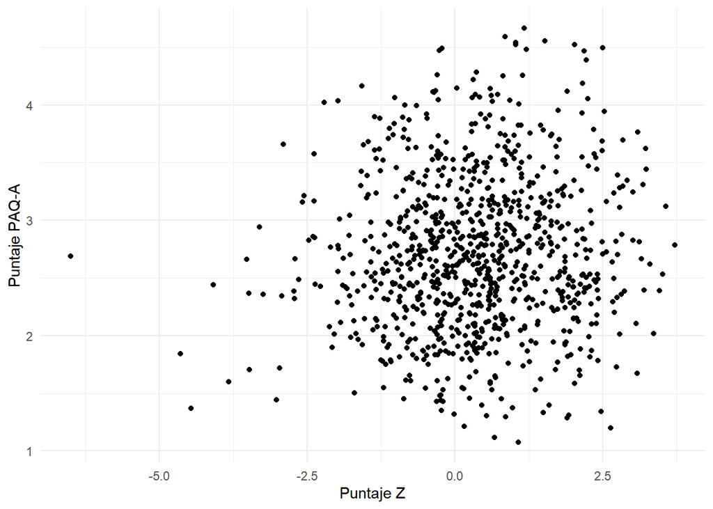

```
## $test
## [1] "Two Sample Weighted T-Test (Welch)"
##
## $coefficients
##     t.value          df     p.value
##  -1.3636968 494.3828400   0.1732836
##
## $additional
##  Difference      Mean.x      Mean.y    Std. Err
## -0.06694346  2.68052447  2.74746793  0.04908970
```

Analisis de correlacion de datos de AFHC con puntaje Z

```
##   correlation    std.err  t.value   p.value
## Y  0.03294807 0.03272076 1.006947 0.3142212
```

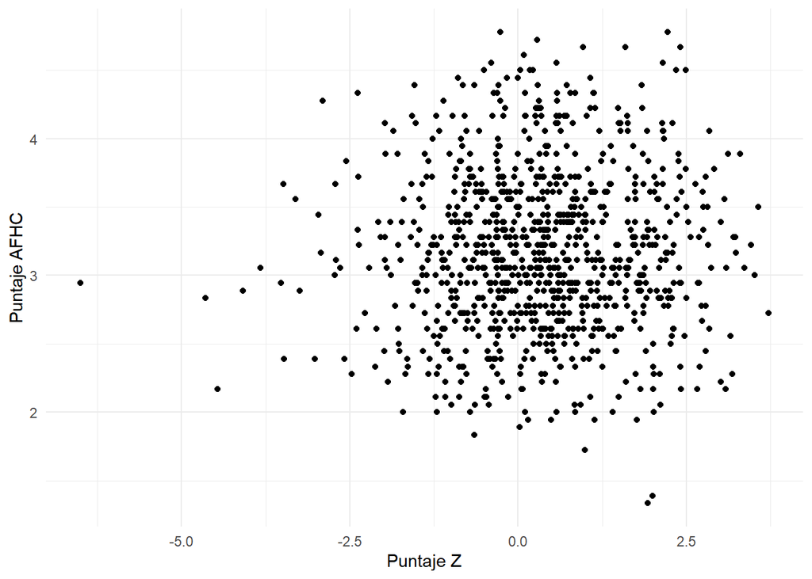

```
## $test
## [1] "Two Sample Weighted T-Test (Welch)"
##
## $coefficients
##     t.value          df     p.value
##  -0.1533063 505.4780276   0.8782179
##
## $additional
##   Difference       Mean.x       Mean.y     Std. Err
## -0.006589844  3.167726525  3.174316370  0.042984820
```

Calculo de la varianza para proporciones

```
## # A tibble: 1 x 5
##     pst     var    SEp MinIntervalp MaxIntervalp
##   <dbl>   <dbl>  <dbl>        <dbl>        <dbl>
## 1 0.305 0.00377 0.0614        0.184        0.425
```

Intervalo de confianza de proporcion de estudiantes con sobrepeso y obesidad para Femenino

```
## # A tibble: 1 x 5
##     pst     var    SEp MinIntervalp MaxIntervalp
##   <dbl>   <dbl>  <dbl>        <dbl>        <dbl>
## 1 0.273 0.00367 0.0606        0.154        0.392
```

Intervalo de confianza de proporcion de estudiantes con sobrepeso y obesidad para Masculino

```
## # A tibble: 1 x 5
##     pst     var    SEp MinIntervalp MaxIntervalp
##   <dbl>   <dbl>  <dbl>        <dbl>        <dbl>
## 1 0.346 0.00385 0.0621        0.225        0.468
```

Intervalo de confianza de proporcion de estudianets con sobrepeso y obesidad para Urbano

```
## # A tibble: 1 x 5
##     pst    var   SEp MinIntervalp MaxIntervalp
##   <dbl>  <dbl> <dbl>        <dbl>        <dbl>
## 1 0.369 0.0115 0.107        0.159        0.580
```

Intervalo de confianza de proporcion de estudiantes con sobrepeso y obesidad para Rural

```
## # A tibble: 1 x 5
##     pst     var    SEp MinIntervalp MaxIntervalp
##   <dbl>   <dbl>  <dbl>        <dbl>        <dbl>
## 1 0.240 0.00544 0.0737       0.0957        0.385
```

Intervalo de confianza de proporcion de estudiantes con sobrepeso y obesidad para Oficial

```
## # A tibble: 1 x 5
##     pst     var    SEp MinIntervalp MaxIntervalp
##   <dbl>   <dbl>  <dbl>        <dbl>        <dbl>
## 1 0.247 0.00506 0.0711        0.108        0.386
```

Intervalo de confianza proporciones de estudiantes con sobrepeso y obesidad para Privado

```
## # A tibble: 1 x 5
##     pst    var   SEp MinIntervalp MaxIntervalp
##   <dbl>  <dbl> <dbl>        <dbl>        <dbl>
## 1 0.434 0.0179 0.134        0.172        0.697
```

Intervalo de confianza proporciones de estudiantes con sobrepeso y obseidad para Cooperativa

```
## # A tibble: 1 x 5
##     pst    var   SEp MinIntervalp MaxIntervalp
##   <dbl>  <dbl> <dbl>        <dbl>        <dbl>
## 1 0.372 0.0312 0.177       0.0251        0.718
```

Intervalo de confianza de proporcion de estudiantes con sobrepeso y obesidad para 1er grado

```
## # A tibble: 1 x 5
##     pst     var    SEp MinIntervalp MaxIntervalp
##   <dbl>   <dbl>  <dbl>        <dbl>        <dbl>
## 1 0.321 0.00410 0.0640        0.195        0.446
```

Intervalo de confianza de proporcion de estudiantes con sobrepeso y obesidad para 2do grado

```
## # A tibble: 1 x 5
##     pst     var    SEp MinIntervalp MaxIntervalp
##   <dbl>   <dbl>  <dbl>        <dbl>        <dbl>
## 1 0.279 0.00342 0.0585        0.165        0.394
```

Intervalo de confianza de proporcion de estudiantes con sobrepeso y obesidad para 3er grado

```
## # A tibble: 1 x 5
##     pst     var    SEp MinIntervalp MaxIntervalp
##   <dbl>   <dbl>  <dbl>        <dbl>        <dbl>
## 1 0.329 0.00372 0.0610        0.210        0.449
```

Intervalo de confianza proporciones de estudiantes con sobrepeso y obesidad para 12 aÃ±os

```
## # A tibble: 1 x 5
##     pst     var    SEp MinIntervalp MaxIntervalp
##   <dbl>   <dbl>  <dbl>        <dbl>        <dbl>
## 1 0.490 0.00851 0.0922        0.310        0.671
```

Intervalo de confianza proporcion de estudiantes con sobrepeso y obesidad para 13 aÃ±os

```
## # A tibble: 1 x 5
##     pst     var    SEp MinIntervalp MaxIntervalp
##   <dbl>   <dbl>  <dbl>        <dbl>        <dbl>
## 1 0.322 0.00410 0.0640        0.197        0.448
```

Intervalo de confianza proporcion de estudiantes con sobrepeso y obesidad para 14 aÃ±os

```
## # A tibble: 1 x 5
##     pst     var    SEp MinIntervalp MaxIntervalp
##   <dbl>   <dbl>  <dbl>        <dbl>        <dbl>
## 1 0.289 0.00382 0.0618        0.168        0.410
```

Intervalo de confianza proporcion de estudiantes con sobrepeso y obesidad para 15 aÃ±os

```
## # A tibble: 1 x 5
##     pst     var    SEp MinIntervalp MaxIntervalp
##   <dbl>   <dbl>  <dbl>        <dbl>        <dbl>
## 1 0.265 0.00331 0.0575        0.152        0.378
```

Intervalo de confianza proporcion de estudiantes con sobrepeso y obesidad para 16 aÃ±os

```
## # A tibble: 1 x 5
##     pst     var    SEp MinIntervalp MaxIntervalp
##   <dbl>   <dbl>  <dbl>        <dbl>        <dbl>
## 1 0.307 0.00385 0.0620        0.186        0.429
```

Prueba de hipotesis para dos colas de Masculino y Femenino con factor de expansion corregido

```
## # A tibble: 1 x 4
##      px    py zvalue pvalue
##   <dbl> <dbl>  <dbl>  <dbl>
## 1 0.346 0.273   2.43 0.0150
```

Prueba de hipotesis para dos colas de Masculino y Femenino con no corregida por factor de expansion

```
## # A tibble: 1 x 4
##      px    py zvalue pvalue
##   <dbl> <dbl>  <dbl>  <dbl>
## 1 0.346 0.273   2.43 0.0150
```

Prueba de hipotesis para urbano rural utilizando proporcion corregida con factor de expansion

```
## # A tibble: 1 x 4
##      px    py zvalue    pvalue
##   <dbl> <dbl>  <dbl>     <dbl>
## 1 0.369 0.240   4.27 0.0000195
```

Prueba de hipotesis para urbano rural utilizando proporcion no corregida con factor de expansion

```
## # A tibble: 1 x 4
##      px    py zvalue    pvalue
##   <dbl> <dbl>  <dbl>     <dbl>
## 1 0.369 0.240   4.29 0.0000178
```

Prueba de chi cuadrada para edad y sobrepeso y obesidad, tratando variable como variable dicotomica 1,0, corregida con peso

```
##       Chisq          df     p.value
## 10.70636373  4.00000000  0.03007004
```

Prueba de chi cuadrada para sexo y sobrepeso y obesidad, tratando variable como variable dicotomica 1,0, corregida por peso

```
##      Chisq         df    p.value
## 6.65142416 1.00000000 0.00990766
```

Prueba de chi cuadrada para area historica y sobrepeso y obesidad, tratando variable como variable dicotomica 1,0 corregida por peso

```
##        Chisq           df      p.value
## 2.127067e+01 1.000000e+00 3.987863e-06
```

Prueba de chi cuadrada para sector historica y sobrepeso y obesidad, tratando variable como variable dicotomica 1,0 corregida por peso

```
##        Chisq           df      p.value
## 3.381526e+01 2.000000e+00 4.540570e-08
```

Prueba de chi cuadrada para grado y sobrepeso y obesidad, tratando variable como variable dicotomica 1,0 corregida por peso

```
##     Chisq        df   p.value
## 0.7010573 2.0000000 0.7043157
```

Prueba de T de comparacion de medias de puntaje z entre hombres y mujeres

```
## $test
## [1] "Two Sample Weighted T-Test (Welch)"
##
## $coefficients
##      t.value           df      p.value
##   1.77136918 885.86059749   0.07684309
##
## $additional
## Difference     Mean.x     Mean.y   Std. Err
## 0.15379350 0.46059246 0.30679895 0.08682182
```

Prueba de T de comparacion de medias de puntaje z entre Urbano y Rural

```
## $test
## [1] "Two Sample Weighted T-Test (Welch)"
##
## $coefficients
##       t.value            df       p.value
##  -3.153768429 877.403891088   0.001666611
##
## $additional
##  Difference      Mean.x      Mean.y    Std. Err
## -0.27220255  0.24022923  0.51243178  0.08631025
```

Pairwise T Test para comparacion de medias de puntajez a de Sector historico

```
## [1] "OFICIAL / COOPERATIVA"
```

```
## $test
## [1] "Two Sample Weighted T-Test (Welch)"
##
## $coefficients
##    t.value         df    p.value
##  -2.614646 235.626884   0.009508
##
## $additional
## Difference     Mean.x     Mean.y   Std. Err
## -0.3248748  0.2156190  0.5404937  0.1242519
```

```
## [1] "OFICIAL / PRIVADO"
```

```
## $test
## [1] "Two Sample Weighted T-Test (Welch)"
##
## $coefficients
##       t.value            df       p.value
## -4.063873e+00  3.588032e+02  5.933192e-05
##
## $additional
## Difference     Mean.x     Mean.y   Std. Err
## -0.4377917  0.2156190  0.6534107  0.1077277
```

```
## [1] "PRIVADO / COOPERATIVA"
```

```
## $test
## [1] "Two Sample Weighted T-Test (Welch)"
##
## $coefficients
##     t.value          df     p.value
##   0.7683264 343.0012825   0.4428219
##
## $additional
## Difference     Mean.x     Mean.y   Std. Err
##  0.1129169  0.6534107  0.5404937  0.1469648
```

Pairwise T Test para comparacion de medias de puntajez por grado

```
## [1] "1ero / 2do"
```

```
## $test
## [1] "Two Sample Weighted T-Test (Welch)"
##
## $coefficients
##      t.value           df      p.value
##   0.01637286 640.68119721   0.98694203
##
## $additional
##  Difference      Mean.x      Mean.y    Std. Err
## 0.001682725 0.402403275 0.400720550 0.102775278
```

```
## [1] "2do / 3ero"
```

```
## $test
## [1] "Two Sample Weighted T-Test (Welch)"
##
## $coefficients
##     t.value          df     p.value
##   0.6395724 550.3403420   0.5227167
##
## $additional
## Difference     Mean.x     Mean.y   Std. Err
## 0.07073723 0.40072055 0.32998332 0.11060081
```

```
## [1] "1ero / 3ero"
```

```
## $test
## [1] "Two Sample Weighted T-Test (Welch)"
##
## $coefficients
##     t.value          df     p.value
##   0.6785652 579.0058620   0.4976845
##
## $additional
## Difference     Mean.x     Mean.y   Std. Err
## 0.07241995 0.40240327 0.32998332 0.10672512
```

Pairwise T Test para comparacion de medias de puntajez de edad

```
## [1] "12 / 13"
```

```
## $test
## [1] "Two Sample Weighted T-Test (Welch)"
##
## $coefficients
##    t.value         df    p.value
##  1.4709607 74.3322814  0.1455226
##
## $additional
## Difference     Mean.x     Mean.y   Std. Err
##  0.2921228  0.7772554  0.4851326  0.1985932
```

```
## [1] "12 / 14"
```

```
## $test
## [1] "Two Sample Weighted T-Test (Welch)"
##
## $coefficients
##     t.value          df     p.value
##  1.75314336 68.32966943  0.08406238
##
## $additional
## Difference     Mean.x     Mean.y   Std. Err
##  0.3404578  0.7772554  0.4367975  0.1941985
```

```
## [1] "12 / 15"
```

```
## $test
## [1] "Two Sample Weighted T-Test (Welch)"
##
## $coefficients
##      t.value           df      p.value
##  3.047591469 72.874625156  0.003212441
##
## $additional
## Difference     Mean.x     Mean.y   Std. Err
##  0.6020360  0.7772554  0.1752194  0.1975448
```

```
## [1] "12 / 16"
```

```
## $test
## [1] "Two Sample Weighted T-Test (Welch)"
##
## $coefficients
##     t.value          df     p.value
##  2.35676219 94.90370744  0.02049022
##
## $additional
## Difference     Mean.x     Mean.y   Std. Err
##  0.5065034  0.7772554  0.2707519  0.2149150
```

```
## [1] "13 / 14"
```

```
## $test
## [1] "Two Sample Weighted T-Test (Welch)"
##
## $coefficients
##     t.value          df     p.value
##   0.4164172 500.6156409   0.6772832
##
## $additional
## Difference     Mean.x     Mean.y   Std. Err
## 0.04833507 0.48513262 0.43679755 0.11607366
```

```
## [1] "13 / 15"
```

```
## $test
## [1] "Two Sample Weighted T-Test (Welch)"
##
## $coefficients
##      t.value           df      p.value
##   2.54884934 491.35533859   0.01111085
##
## $additional
## Difference     Mean.x     Mean.y   Std. Err
##  0.3099132  0.4851326  0.1752194  0.1215895
```

```
## [1] "13 / 16"
```

```
## $test
## [1] "Two Sample Weighted T-Test (Welch)"
##
## $coefficients
##     t.value          df     p.value
##   1.4470499 237.6549041   0.1492007
##
## $additional
## Difference     Mean.x     Mean.y   Std. Err
##  0.2143807  0.4851326  0.2707519  0.1481502
```

```
## [1] "14 / 15"
```

```
## $test
## [1] "Two Sample Weighted T-Test (Welch)"
##
## $coefficients
##      t.value           df      p.value
##   2.28910817 510.45537769   0.02248055
##
## $additional
## Difference     Mean.x     Mean.y   Std. Err
##  0.2615781  0.4367975  0.1752194  0.1142708
```

```
## [1] "14 / 16"
```

```
## $test
## [1] "Two Sample Weighted T-Test (Welch)"
##
## $coefficients
##     t.value          df     p.value
##   1.1676490 213.4077024   0.2442513
##
## $additional
## Difference     Mean.x     Mean.y   Std. Err
##  0.1660456  0.4367975  0.2707519  0.1422051
```

```
## [1] "15 / 16"
```

```
## $test
## [1] "Two Sample Weighted T-Test (Welch)"
##
## $coefficients
##     t.value          df     p.value
##  -0.6510241 232.0172772   0.5156752
##
## $additional
##  Difference      Mean.x      Mean.y    Std. Err
## -0.09553251  0.17521942  0.27075193  0.14674190
```

Prueba de hipotesis

```
## # A tibble: 1 x 4
##      px pnull zscore pvalue
##   <dbl> <dbl>  <dbl>  <dbl>
## 1 0.305  0.25  0.891  0.373
```

Prueba de T de comparacion de medias de paq a entre hombres y mujeres

```
## $test
## [1] "Two Sample Weighted T-Test (Welch)"
##
## $coefficients
##      t.value           df      p.value
## 6.014969e+00 9.325103e+02 2.581243e-09
##
## $additional
## Difference     Mean.x     Mean.y   Std. Err
## 0.25958405 2.83461498 2.57503094 0.04315634
```

Prueba de T de comparacion de medias de paq a entre Urbano y Rural

```
## $test
## [1] "Two Sample Weighted T-Test (Welch)"
##
## $coefficients
##     t.value          df     p.value
##   0.2458495 905.7218221   0.8058544
##
## $additional
## Difference     Mean.x     Mean.y   Std. Err
## 0.01083512 2.70673751 2.69590239 0.04407216
```

Pairwise T Test para comparacion de medias de paq a de Sector historico

```
## [1] "OFICIAL / COOPERATIVA"
```

```
## $test
## [1] "Two Sample Weighted T-Test (Welch)"
##
## $coefficients
##      t.value           df      p.value
##  -2.53179258 247.57431938   0.01196764
##
## $additional
##  Difference      Mean.x      Mean.y    Std. Err
## -0.15846318  2.68010648  2.83856967  0.06258932
```

```
## [1] "OFICIAL / PRIVADO"
```

```
## $test
## [1] "Two Sample Weighted T-Test (Welch)"
##
## $coefficients
##     t.value          df     p.value
##   0.5476923 392.6756176   0.5842144
##
## $additional
## Difference     Mean.x     Mean.y   Std. Err
## 0.02909110 2.68010648 2.65101538 0.05311578
```

```
## [1] "PRIVADO / COOPERATIVA"
```

```
## $test
## [1] "Two Sample Weighted T-Test (Welch)"
##
## $coefficients
##       t.value            df       p.value
##  -2.604541217 335.819289637   0.009608617
##
## $additional
##  Difference      Mean.x      Mean.y    Std. Err
## -0.18755429  2.65101538  2.83856967  0.07201049
```

Pairwise T Test para comparacion de medias de paq a de grado

```
## [1] "1ero / 2do"
```

```
## $test
## [1] "Two Sample Weighted T-Test (Welch)"
##
## $coefficients
##     t.value          df     p.value
##   2.2160947 638.7307057   0.0270367
##
## $additional
## Difference     Mean.x     Mean.y   Std. Err
## 0.11299341 2.81706009 2.70406669 0.05098762
```

```
## [1] "2do / 3ero"
```

```
## $test
## [1] "Two Sample Weighted T-Test (Welch)"
##
## $coefficients
##      t.value           df      p.value
## 3.065456e+00 5.458438e+02 2.280897e-03
##
## $additional
## Difference     Mean.x     Mean.y   Std. Err
## 0.17169428 2.70406669 2.53237241 0.05600939
```

```
## [1] "1ero / 3ero"
```

```
## $test
## [1] "Two Sample Weighted T-Test (Welch)"
##
## $coefficients
##      t.value           df      p.value
## 5.277532e+00 5.655016e+02 1.868845e-07
##
## $additional
## Difference     Mean.x     Mean.y   Std. Err
## 0.28468769 2.81706009 2.53237241 0.05394334
```

Pairwise T Test para comparacion de medias de paq a de edad

```
## [1] "12 / 13"
```

```
## $test
## [1] "Two Sample Weighted T-Test (Welch)"
##
## $coefficients
##    t.value         df    p.value
## -0.8496624 69.5757432  0.3984271
##
## $additional
##  Difference      Mean.x      Mean.y    Std. Err
## -0.09101514  2.70269775  2.79371289  0.10711919
```

```
## [1] "12 / 14"
```

```
## $test
## [1] "Two Sample Weighted T-Test (Welch)"
##
## $coefficients
##     t.value          df     p.value
## -0.05891537 66.24525146  0.95319688
##
## $additional
##  Difference      Mean.x      Mean.y    Std. Err
## -0.00622967  2.70269775  2.70892742  0.10573930
```

```
## [1] "12 / 15"
```

```
## $test
## [1] "Two Sample Weighted T-Test (Welch)"
##
## $coefficients
##    t.value         df    p.value
##  0.7321996 67.9431341  0.4665651
##
## $additional
## Difference     Mean.x     Mean.y   Std. Err
## 0.07794457 2.70269775 2.62475318 0.10645263
```

```
## [1] "12 / 16"
```

```
## $test
## [1] "Two Sample Weighted T-Test (Welch)"
##
## $coefficients
##    t.value         df    p.value
##  0.5574259 92.6546027  0.5785807
##
## $additional
## Difference     Mean.x     Mean.y   Std. Err
## 0.06523324 2.70269775 2.63746450 0.11702586
```

```
## [1] "13 / 14"
```

```
## $test
## [1] "Two Sample Weighted T-Test (Welch)"
##
## $coefficients
##     t.value          df     p.value
##   1.4392486 507.6492297   0.1506964
##
## $additional
## Difference     Mean.x     Mean.y   Std. Err
## 0.08478547 2.79371289 2.70892742 0.05890954
```

```
## [1] "13 / 15"
```

```
## $test
## [1] "Two Sample Weighted T-Test (Welch)"
##
## $coefficients
##      t.value           df      p.value
## 2.807547e+00 4.908953e+02 5.190737e-03
##
## $additional
## Difference     Mean.x     Mean.y   Std. Err
## 0.16895971 2.79371289 2.62475318 0.06018054
```

```
## [1] "13 / 16"
```

```
## $test
## [1] "Two Sample Weighted T-Test (Welch)"
##
## $coefficients
##      t.value           df      p.value
##   2.01975403 222.63080104   0.04460724
##
## $additional
## Difference     Mean.x     Mean.y   Std. Err
## 0.15624839 2.79371289 2.63746450 0.07736011
```

```
## [1] "14 / 15"
```

```
## $test
## [1] "Two Sample Weighted T-Test (Welch)"
##
## $coefficients
##     t.value          df     p.value
##   1.4591134 517.2911742   0.1451408
##
## $additional
## Difference     Mean.x     Mean.y   Std. Err
## 0.08417424 2.70892742 2.62475318 0.05768862
```

```
## [1] "14 / 16"
```

```
## $test
## [1] "Two Sample Weighted T-Test (Welch)"
##
## $coefficients
##     t.value          df     p.value
##   0.9473087 208.1848679   0.3445798
##
## $additional
## Difference     Mean.x     Mean.y   Std. Err
## 0.07146291 2.70892742 2.63746450 0.07543783
```

```
## [1] "15 / 16"
```

```
## $test
## [1] "Two Sample Weighted T-Test (Welch)"
##
## $coefficients
##     t.value          df     p.value
##  -0.1663036 215.2602618   0.8680742
##
## $additional
##  Difference      Mean.x      Mean.y    Std. Err
## -0.01271133  2.62475318  2.63746450  0.07643447
```

Prueba de T de comparacion de medias de afhc a entre hombres y mujeres

```
## $test
## [1] "Two Sample Weighted T-Test (Welch)"
##
## $coefficients
##     t.value          df     p.value
##   0.7672913 932.3914586   0.4431026
##
## $additional
## Difference     Mean.x     Mean.y   Std. Err
## 0.02980901 3.18508375 3.15527474 0.03884967
```

Prueba de T de comparacion de medias de afhc entre Urbano y Rural

```
## $test
## [1] "Two Sample Weighted T-Test (Welch)"
##
## $coefficients
##      t.value           df      p.value
## 2.595884e+00 8.941686e+02 9.589524e-03
##
## $additional
## Difference     Mean.x     Mean.y   Std. Err
## 0.10074129 3.22203664 3.12129535 0.03880808
```

Pairwise T Test para comparacion de medias de afhc a de Sector historico

```
## [1] "OFICIAL / COOPERATIVA"
```

```
## $test
## [1] "Two Sample Weighted T-Test (Welch)"
##
## $coefficients
##     t.value          df     p.value
##   1.0131319 253.3197925   0.3119639
##
## $additional
## Difference     Mean.x     Mean.y   Std. Err
##  0.0556561  3.2110005  3.1553444  0.0549347
```

```
## [1] "OFICIAL / PRIVADO"
```

```
## $test
## [1] "Two Sample Weighted T-Test (Welch)"
##
## $coefficients
##      t.value           df      p.value
## 2.748232e+00 4.098236e+02 6.256458e-03
##
## $additional
## Difference     Mean.x     Mean.y   Std. Err
## 0.12696490 3.21100047 3.08403557 0.04619876
```

```
## [1] "PRIVADO / COOPERATIVA"
```

```
## $test
## [1] "Two Sample Weighted T-Test (Welch)"
##
## $coefficients
##     t.value          df     p.value
##  -1.1426075 332.4183595   0.2540239
##
## $additional
##  Difference      Mean.x      Mean.y    Std. Err
## -0.07130880  3.08403557  3.15534437  0.06240883
```

Pairwise T Test para comparacion de medias de afhc por grado

```
## [1] "1ero / 2do"
```

```
## $test
## [1] "Two Sample Weighted T-Test (Welch)"
##
## $coefficients
##      t.value           df      p.value
## 3.507547e+00 6.473735e+02 4.835524e-04
##
## $additional
## Difference     Mean.x     Mean.y   Std. Err
## 0.15939339 3.24295563 3.08356225 0.04544298
```

```
## [1] "2do / 3ero"
```

```
## $test
## [1] "Two Sample Weighted T-Test (Welch)"
##
## $coefficients
##    t.value         df    p.value
##  -1.604774 544.903979   0.109123
##
## $additional
##  Difference      Mean.x      Mean.y    Std. Err
## -0.07902546  3.08356225  3.16258771  0.04924399
```

```
## [1] "1ero / 3ero"
```

```
## $test
## [1] "Two Sample Weighted T-Test (Welch)"
##
## $coefficients
##      t.value           df      p.value
##   1.66896344 576.02924301   0.09566799
##
## $additional
## Difference     Mean.x     Mean.y   Std. Err
## 0.08036792 3.24295563 3.16258771 0.04815439
```

Pairwise T Test para comparacion de medias de afhc de edad

```
## [1] "12 / 13"
```

```
## $test
## [1] "Two Sample Weighted T-Test (Welch)"
##
## $coefficients
##    t.value         df    p.value
## -0.1865487 70.1582105  0.8525529
##
## $additional
##  Difference      Mean.x      Mean.y    Std. Err
## -0.01795106  3.17025620  3.18820726  0.09622720
```

```
## [1] "12 / 14"
```

```
## $test
## [1] "Two Sample Weighted T-Test (Welch)"
##
## $coefficients
##     t.value          df     p.value
##  0.02042479 65.88455079  0.98376624
##
## $additional
##  Difference      Mean.x      Mean.y    Std. Err
## 0.001933129 3.170256202 3.168323074 0.094646186
```

```
## [1] "12 / 15"
```

```
## $test
## [1] "Two Sample Weighted T-Test (Welch)"
##
## $coefficients
##    t.value         df    p.value
##  0.3867636 65.8116480  0.7001790
##
## $additional
## Difference     Mean.x     Mean.y   Std. Err
## 0.03659985 3.17025620 3.13365636 0.09463106
```

```
## [1] "12 / 16"
```

```
## $test
## [1] "Two Sample Weighted T-Test (Welch)"
##
## $coefficients
##    t.value         df    p.value
## -0.3757514 94.0913652  0.7079476
##
## $additional
##  Difference      Mean.x      Mean.y    Std. Err
## -0.03961675  3.17025620  3.20987295  0.10543342
```

```
## [1] "13 / 14"
```

```
## $test
## [1] "Two Sample Weighted T-Test (Welch)"
##
## $coefficients
##     t.value          df     p.value
##   0.3755522 504.1345519   0.7074078
##
## $additional
## Difference     Mean.x     Mean.y   Std. Err
## 0.01988419 3.18820726 3.16832307 0.05294654
```

```
## [1] "13 / 15"
```

```
## $test
## [1] "Two Sample Weighted T-Test (Welch)"
##
## $coefficients
##     t.value          df     p.value
##   1.0308284 485.3654994   0.3031347
##
## $additional
## Difference     Mean.x     Mean.y   Std. Err
## 0.05455091 3.18820726 3.13365636 0.05291949
```

```
## [1] "13 / 16"
```

```
## $test
## [1] "Two Sample Weighted T-Test (Welch)"
##
## $coefficients
##     t.value          df     p.value
##  -0.3075812 221.9056123   0.7586895
##
## $additional
##  Difference      Mean.x      Mean.y    Std. Err
## -0.02166569  3.18820726  3.20987295  0.07043892
```

```
## [1] "14 / 15"
```

```
## $test
## [1] "Two Sample Weighted T-Test (Welch)"
##
## $coefficients
##     t.value          df     p.value
##   0.6935150 520.7637503   0.4882956
##
## $additional
## Difference     Mean.x     Mean.y   Std. Err
## 0.03466672 3.16832307 3.13365636 0.04998698
```

```
## [1] "14 / 16"
```

```
## $test
## [1] "Two Sample Weighted T-Test (Welch)"
##
## $coefficients
##     t.value          df     p.value
##  -0.6086715 203.3762194   0.5434214
##
## $additional
##  Difference      Mean.x      Mean.y    Std. Err
## -0.04154988  3.16832307  3.20987295  0.06826322
```

```
## [1] "15 / 16"
```

```
## $test
## [1] "Two Sample Weighted T-Test (Welch)"
##
## $coefficients
##     t.value          df     p.value
##  -1.1168537 202.0481643   0.2653833
##
## $additional
##  Difference      Mean.x      Mean.y    Std. Err
## -0.07621660  3.13365636  3.20987295  0.06824224
```